# Sharma_Assignment_3

[figure not shown]

## MSDS458 Research Assignment 3

### Project Nature & Content: Language Modeling with RNN:

This assignment concerns natural language processing. You are asked to create deep neural networks for language processing and to analyze how various factors affect the fitting and ultimate test set performance of these networks.

Network Topologies. Think in terms of exploring alternative network structures/topologies, such as (1) dense versus recurrent neural networks, (2) dense versus one-dimensional convolutional neural networks, and/or (3) recurrent neural networks with and without long short-term memory. Explain your motivation for choosing each topology.

Among the network topologies (structures) you test in this assignment, there should be at least one network with the ability to take the sequence of words into consideration. A useful exercise is to compare processing requirements and predictive accuracy of dense versus recurrent neural networks with long short-term memory.

It is suggested that you work with a text classification problem using the AG’s news topic classification data set. Begin by fitting a fully connected (dense) network, evaluating alternative network structures in terms of their classification performance. Then pursue either a one-dimensional convolutional neural network (CNN) or a recurrent neural network (RNN or LSTM) to classify the same documents. Compare the performance of the word-sequence-enhanced model to the fully-connected model. Sequence models are discussed in chapter 6 of Chollet (2018).

Regarding data sets for natural language processing tasks (in particular, document classification), consider using https://www.tensorflow.org/datasets/catalog/ag_news_subset Links to an external site.. The goal is to compare several NLP algorithms for Reuters data – multi-class classification problem. First, do EDA to understand how many topics (classes) are there in the data. Also understand how many documents are there in each class. In all the experiments, you may want to hold some parameters constants – eg. truncation of the documents to 128 tokens, the batch size to 100, the number of epochs to 10, same optimizer, same loss function of cross entropy, so that the comparisons are fair.

**Experiments A: EDA:** For NLP projects, it is very important to do extensive EDA and do the preprocessing before defining models. These are the suggestions.

(a) Vocabulary Size: Tweak the vocabulary size, at least 3 levels.

(b) Editing the Vocabulary: Try unedited most frequent words, VERSUS edit the list by deleting the most frequent words such as article, ‘the’, ‘a’, etc.

(c) Output sequence length: Use the default VERSUS set it to a fixed number

**Experiments B: RNN:** Try several experiments by tweaking (i) architecture (ii) Bidirectional/unidirectional & other hyper parameters, including regularization.

**Experiments C: LSTM:** Try several experiments by tweaking (i) architecture (ii) Bidirectional/unidirectional & other hyper parameters, including regularization.

**Experiment D: 1D CNN**

**Result:** Create a table with the accuracy and loss for train/test/validation & process time for all the models

(Optional) Compare the test set performance and training time for models that begin with one-hot encoding versus models that begin with word embeddings from a public-domain source (pre-trained word embeddings). Methods for obtaining and working with word embeddings are provided under Modules / Technology Resources and in Chollet (2018) chapter 6.

Hyperparameter Settings. Within each network topology, evaluate alternative settings for hyperparameters. Understand that the tuning of hyperparameter settings may be best accomplished by dividing the available data into training, validation, and test sets.

For each network under study, report on its structure and hyperparameter settings. Report on the time it takes to train each network and the performance of that network in the test set.

Visualizations. Employ visualizations to examine the performance of each network under study. Show training and validation set results (loss/cost and performance/accuracy) across epochs.

**Management Problem.** Suppose you are asked by your current employer to develop a conversational agent or chatbot to assist customer support representatives. What advice would you give management about such development? What kinds of methods and models would be needed? Would this be a substantial development project? Do you have any ideas about the information infrastructure needed to support conversational agents in a production environment?

(Optional) Think about the possibilities for a generative language model using these same data. That is, drawing on methods described in chapter 8 of the Chollet (2018, pages 271-279), consider how you might develop a software robot to write movie reviews or news articles. Describe what you would do to build such a model. If time permits, start with a few words and use a language model to generate subsequent words. Try various degrees of randomness (temperature, as described by Chollet) for the generated text sequences.

### Import packages needed

```python
import datetime
from packaging import version
from collections import Counter
import numpy as np
import pandas as pd
import time

import matplotlib.pyplot as plt
import matplotlib as mpl
import seaborn as sns

from sklearn.metrics import confusion_matrix, classification_report
from sklearn.preprocessing import StandardScaler
from sklearn.decomposition import PCA
from sklearn.manifold import TSNE
from sklearn.ensemble import RandomForestClassifier
from sklearn.metrics import mean_squared_error as MSE
from sklearn.metrics import accuracy_score

import tensorflow as tf
from tensorflow import keras
from tensorflow.keras import layers
import tensorflow_datasets as tfds
import nltk
from nltk.corpus import stopwords
import warnings
warnings.filterwarnings('ignore')
```

```python
%matplotlib inline
np.set_printoptions(precision=3, suppress=True)
```

## Verify TensorFlow Version

```python
print("This notebook requires TensorFlow 2.0 or above")
print("TensorFlow version: ", tf.__version__)
assert version.parse(tf.__version__).release[0] >=2
```

```
This notebook requires TensorFlow 2.0 or above
TensorFlow version:  2.17.0
```

```python
print("Keras version: ", keras.__version__)
```

```
Keras version:  3.6.0
```

## Visualization Utility Functions

```python
def print_validation_report(test_labels, predictions):
    print("Classification Report")
    print(classification_report(test_labels, predictions))
    print('Accuracy Score: {}'.format(accuracy_score(test_labels, predictions)))
    print('Root Mean Square Error: {}'.format(np.sqrt(MSE(test_labels, predictions))))

def plot_confusion_matrix(y_true, y_pred):
    mtx = confusion_matrix(y_true, y_pred)
    fig, ax = plt.subplots(figsize=(8,8))
    sns.heatmap(mtx, annot=True, fmt='d', linewidths=.75,  cbar=False, ax=ax,cmap='Blues',linecolor='white')
    #  square=True,
    plt.ylabel('true label')
    plt.xlabel('predicted label')

def plot_graphs(history, metric):
  plt.plot(history.history[metric])
  plt.plot(history.history['val_'+metric], '')
  plt.xlabel("Epochs")
  plt.ylabel(metric)
  plt.legend([metric, 'val_'+metric])
```

**Mount Google Drive**

```python
#from google.colab import drive
#drive.mount('/content/gdrive')
```

```python
!tfds build --register_checksums --datasets=ag_news_subset
```

[output not shown]

**TensorFlow Datasets Information**

Get all the words in the documents (as well as the number of words in each document) by using the encoder to get the indices associated with each token and then translating the indices to tokens. But first we need to get the "unpadded" new articles so that we can get their length.

```python
# https://www.tensorflow.org/datasets/splits
# The full `train` and `test` splits, interleaved together.
ri = tfds.core.ReadInstruction('train') + tfds.core.ReadInstruction('test')
dataset_all, info = tfds.load('ag_news_subset', with_info=True,  split=ri, as_supervised=True)
text_only_dataset_all = dataset_all.map(lambda x, y: x)
```

**Exploratory Analysis AG News Subset**

Get information about the ag_news_subset dataset. We combined the training and test data for a total of 127,600 news articles.

```python
print(info)
```

```
tfds.core.DatasetInfo(
    name='ag_news_subset',
    full_name='ag_news_subset/1.0.0',
    description="""
    AG is a collection of more than 1 million news articles. News articles have been
    gathered from more than 2000 news sources by ComeToMyHead in more than 1 year of
    activity. ComeToMyHead is an academic news search engine which has been running
    since July, 2004. The dataset is provided by the academic comunity for research
    purposes in data mining (clustering, classification, etc), information retrieval
    (ranking, search, etc), xml, data compression, data streaming, and any other
    non-commercial activity. For more information, please refer to the link
    http://www.di.unipi.it/~gulli/AG_corpus_of_news_articles.html .

    The AG's news topic classification dataset is constructed by Xiang Zhang
    (xiang.zhang@nyu.edu) from the dataset above. It is used as a text
    classification benchmark in the following paper: Xiang Zhang, Junbo Zhao, Yann
    LeCun. Character-level Convolutional Networks for Text Classification. Advances
    in Neural Information Processing Systems 28 (NIPS 2015).

    The AG's news topic classification dataset is constructed by choosing 4 largest
    classes from the original corpus. Each class contains 30,000 training samples
    and 1,900 testing samples. The total number of training samples is 120,000 and
    testing 7,600.
    """,
    homepage='https://arxiv.org/abs/1509.01626',
    data_dir='/Users/sachinsharma/tensorflow_datasets/ag_news_subset/1.0.0',
    file_format=tfrecord,
    download_size=Unknown size,
    dataset_size=35.79 MiB,
    features=FeaturesDict({
        'description': Text(shape=(), dtype=string),
        'label': ClassLabel(shape=(), dtype=int64, num_classes=4),
        'title': Text(shape=(), dtype=string),
    }),
    supervised_keys=('description', 'label'),
    disable_shuffling=False,
    splits={
        'test': <SplitInfo num_examples=7600, num_shards=1>,
        'train': <SplitInfo num_examples=120000, num_shards=1>,
    },
    citation="""@misc{zhang2015characterlevel,
        title={Character-level Convolutional Networks for Text Classification},
        author={Xiang Zhang and Junbo Zhao and Yann LeCun},
        year={2015},
        eprint={1509.01626},
        archivePrefix={arXiv},
        primaryClass={cs.LG}
    }""",
)
```

```python
tfds.as_dataframe(dataset_all.take(10), info)
```

```
2024-11-03 15:05:43.353797: W tensorflow/core/kernels/data/cache_dataset_ops.cc:913] The calling iterator did not fully read the dataset being cached. In order to avoid unexpected truncation of the dataset, the partially cached contents of the dataset  will be discarded. This can happen if you have …
2024-11-03 15:05:43.354078: I tensorflow/core/framework/local_rendezvous.cc:404] Local rendezvous is aborting with status: OUT_OF_RANGE: End of sequence
```

|  | description | label |
| --- | --- | --- |
| 0 | AMD #39;s new dual-core Opteron chip is designed mainly for corporate computing applications, including databases, Web services, and financial transactions. | 3 (Sci/Tech) |
| 1 | Reuters - Major League Baseball\Monday announced a decision on the appeal filed by Chicago Cubs\pitcher Kerry Wood regarding a suspension stemming from an\incident earlier this season. | 1 (Sports) |
| 2 | President Bush #39;s quot;revenue-neutral quot; tax reform needs losers to balance its winners, and people claiming the federal deduction for state and local taxes may be in administration planners #3… | 2 (Business) |
| 3 | Britain will run out of leading scientists unless science education is improved, says Professor Colin Pillinger. | 3 (Sci/Tech) |
| 4 | London, England (Sports Network) - England midfielder Steven Gerrard injured his groin late in Thursday #39;s training session, but is hopeful he will be ready for Saturday #39;s World Cup qualifier a… | 1 (Sports) |
| 5 | TOKYO - Sony Corp. is banking on the \$3 billion deal to acquire Hollywood studio Metro-Goldwyn-Mayer Inc... | 0 (World) |
| 6 | Giant pandas may well prefer bamboo to laptops, but wireless technology is helping researchers in China in their efforts to protect the engandered animals living in the remote Wolong Nature Reserve. | 3 (Sci/Tech) |
| 7 | VILNIUS, Lithuania - Lithuania #39;s main parties formed an alliance to try to keep a Russian-born tycoon and his populist promises out of the government in Sunday #39;s second round of parliamentary … | 0 (World) |
| 8 | Witnesses in the trial of a US soldier charged with abusing prisoners at Abu Ghraib have told the court that the CIA sometimes directed abuse and orders were received from military command to toughen … | 0 (World) |
| 9 | Dan Olsen of Ponte Vedra Beach, Fla., shot a 7-under 65 Thursday to take a one-shot lead after two rounds of the PGA Tour qualifying tournament. | 1 (Sports) |

**Review Labels (Categories)**

```python
# classes dictionary
categories = dict(enumerate(info.features["label"].names))
categories
```

```
{0: 'World', 1: 'Sports', 2: 'Business', 3: 'Sci/Tech'}
```

### Review Class Balance

The 127,600 news articles are evenly distributed among the 4 categories

```python
train_categories = [categories[label] for label in dataset_all.map(lambda text, label: label).as_numpy_iterator()]
Counter(train_categories).most_common()
```

```
2024-11-03 15:05:47.744305: I tensorflow/core/framework/local_rendezvous.cc:404] Local rendezvous is aborting with status: OUT_OF_RANGE: End of sequence
```

```
[('Sci/Tech', 31900), ('Sports', 31900), ('Business', 31900), ('World', 31900)]
```

We will use the layers.TextVectorization layer to transform each news article into a "list" of non-negative integers representing the tokens in the news article.

For the purpose of training our models each such "encoding" will have a fixed length corresponding to the news article(s) with the most tokens. Shorter articles will be right-padded with zeros in the encoding. Also to speed up the training process, we will set max_tokens = 1000 so that words not in the vabulary set of top 1000 most common tokes are encoded as 1. But first we set max_tokens = None (which is the default value) in order to get the vocabulary size of the corpus.

```python
%%time
encoder = layers.TextVectorization(max_tokens=None)
encoder.adapt(text_only_dataset_all)
vocab = np.array(encoder.get_vocabulary())
```

```
CPU times: user 2min 51s, sys: 4.13 s, total: 2min 55s
Wall time: 2min 49s
```

```python
print(f"There are {len(vocab)} vocabulary words in the corpus.")
```

```
There are 95976 vocabulary words in the corpus.
```

```python
vocab[:20]
```

```
array(['', '[UNK]', 'the', 'a', 'to', 'of', 'in', 'and', 'on', 'for',
       'that', '39s', 'with', 'its', 'as', 'at', 'is', 'said', 'by', 'it'],
      dtype='<U150')
```

Let us get the total number of words in the corpus and the sizes of the news articles

```python
%%time
doc_sizes = []
corpus = []
for example, _ in dataset_all.as_numpy_iterator():
  enc_example = encoder(example)
  doc_sizes.append(len(enc_example))
  corpus+=list(enc_example.numpy())
```

```
CPU times: user 2min 53s, sys: 2.36 s, total: 2min 55s
Wall time: 2min 51s
```

```
2024-11-03 15:11:29.441728: I tensorflow/core/framework/local_rendezvous.cc:404] Local rendezvous is aborting with status: OUT_OF_RANGE: End of sequence
```

```python
print(f"There are {len(corpus)} words in the corpus of {len(doc_sizes)} news articles.")
print(f"Each news article has between {min(doc_sizes)} and {max(doc_sizes)} tokens in it.")
```

```
There are 3909695 words in the corpus of 127600 news articles.
Each news article has between 3 and 173 tokens in it.
```

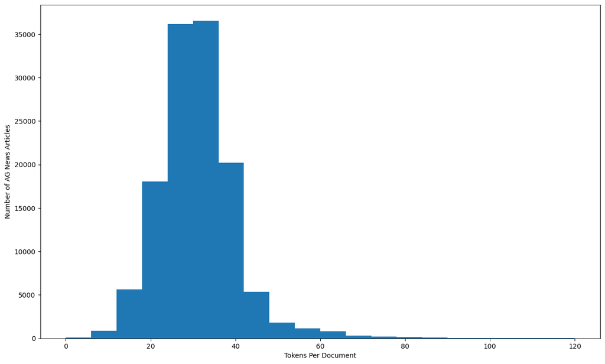

```python
plt.figure(figsize=(15,9))
plt.hist(doc_sizes, bins=20,range = (0,120))
plt.xlabel("Tokens Per Document")
plt.ylabel("Number of AG News Articles");
```

Encode the news articles using the top 1000 most common words in the corpus

```python
%%time
encoder_1000 = layers.TextVectorization(max_tokens=1000)
encoder_1000.adapt(text_only_dataset_all)
vocab_1000 = np.array(encoder_1000.get_vocabulary());
```

```
CPU times: user 2min 49s, sys: 4.8 s, total: 2min 54s
Wall time: 2min 47s
```

```python
vocab_1000[:20]
```

```
array(['', '[UNK]', 'the', 'a', 'to', 'of', 'in', 'and', 'on', 'for',
       'that', '39s', 'with', 'its', 'as', 'at', 'is', 'said', 'by', 'it'],
      dtype='<U14')
```

We encode the same example as before using the new encoder. Note that there are now 5 out of vocabulary words.

```python
example = "the dog ran after a red ball as it rolled by the hat on the ground."
encoder_1000(example)
```

```
<tf.Tensor: shape=(16,), dtype=int64, numpy=
array([  2,   1,   1,  29,   3, 232,   1,  14,  19,   1,  18,   2,   1,
         8,   2, 999])>
```

```python
for word in example.split():
  print(f'"{word}" is {"*not* " if word not in vocab_1000  else ""}in the vocabulary.')
```

```
"the" is in the vocabulary.
"dog" is *not* in the vocabulary.
"ran" is *not* in the vocabulary.
"after" is in the vocabulary.
"a" is in the vocabulary.
"red" is in the vocabulary.
"ball" is *not* in the vocabulary.
"as" is in the vocabulary.
"it" is in the vocabulary.
"rolled" is *not* in the vocabulary.
"by" is in the vocabulary.
"the" is in the vocabulary.
"hat" is *not* in the vocabulary.
"on" is in the vocabulary.
"the" is in the vocabulary.
"ground." is *not* in the vocabulary.
```

We want to determine the number of non-vocabulary words in each news articles (denoted by 1s in the encoding)

```python
%%time
doc1000_sizes = []
corpus1000 = []
count1000=0
useless = 0
# stop = 0
percents = []
for example, _ in dataset_all.as_numpy_iterator():
  # stop+=1
  # if stop > 5: break
  enc_example = encoder_1000(example)
  num_ones = tf.math.count_nonzero(enc_example==1).numpy()
  percent_ones = round(num_ones*100/len(enc_example))
  # print(f"{percent_ones}%")
  percents.append(percent_ones)

  s = set(list(enc_example.numpy()))
  if s == {1}: useless+=1

  doc1000_sizes.append(len(enc_example))
  corpus1000+=list(enc_example.numpy())

  count1000 += tf.math.count_nonzero(enc_example>1)
```

```
CPU times: user 3min 16s, sys: 2.62 s, total: 3min 18s
Wall time: 3min 15s
```

```python
print(f"Each news article has between {min(doc1000_sizes)} and {max(doc1000_sizes)} tokens in it.")
```

```
Each news article has between 3 and 173 tokens in it.
```

```python
Counter(percents).most_common(10)
np.unique(percents, return_counts=True)
```

```
(array([  0,   3,   4,   5,   6,   7,   8,   9,  10,  11,  12,  13,  14,
         15,  16,  17,  18,  19,  20,  21,  22,  23,  24,  25,  26,  27,
         28,  29,  30,  31,  32,  33,  34,  35,  36,  37,  38,  39,  40,
         41,  42,  43,  44,  45,  46,  47,  48,  49,  50,  51,  52,  53,
         54,  55,  56,  57,  58,  59,  60,  61,  62,  63,  64,  65,  66,
         67,  68,  69,  70,  71,  72,  73,  74,  75,  76,  77,  78,  79,
         80,  81,  82,  83,  84,  85,  86,  87,  88,  89,  90,  91,  92,
         93,  95,  97, 100]),
 array([  12,    5,   20,   29,   49,   71,  120,  137,  172,  274,  486,
         368,  682,  777,  828, 1346, 1376, 2123, 1610, 2863, 2687, 3018,
        3957, 3315, 4605, 3934, 4148, 5737, 4954, 5072, 6123, 6165, 3255,
        5095, 4596, 3438, 5880, 4205, 3109, 4063, 3555, 3030, 2904, 2294,
        1967, 1716, 2174,  368, 2486,  234, 1246,  747,  573,  547,  520,
         441,  348,  217,  250,  135,  234,   49,  131,  101,   11,  135,
          40,   62,   33,   53,    8,   34,   10,   55,   10,    8,   15,
           3,   27,    9,    5,   19,    1,    8,   12,    6,   16,   11,
           5,    4,    2,    3,    1,    1,   22]))
```

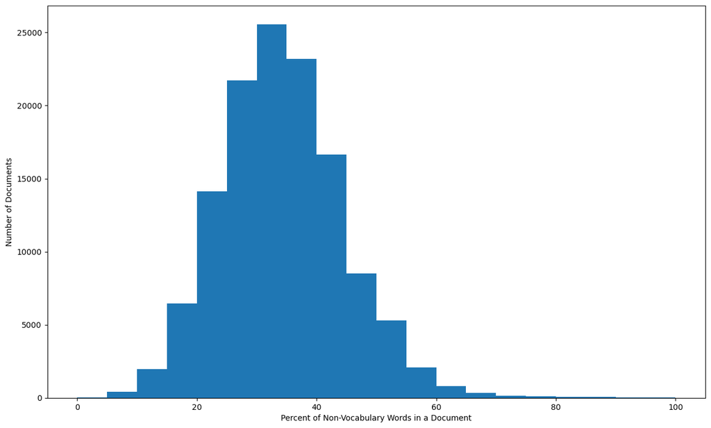

```python
plt.figure(figsize=(15,9))
plt.hist(percents, 20)
plt.ylabel('Number of Documents')
plt.xlabel('Percent of Non-Vocabulary Words in a Document');
```

```python
print(f"There are {count1000} top {len(vocab_1000)} vocabulary words in the corpus.")
```

```
There are 2602670 top 1000 vocabulary words in the corpus.
```

**Preprocessing Data Create Input Pipeline**

```python
dataset, info = tfds.load('ag_news_subset', with_info=True,  split=['train[:95%]','train[95%:]', 'test'],
                          as_supervised=True)
train_dataset, validation_dataset, test_dataset = dataset
text_only_train_ds = train_dataset.map(lambda x, y: x)
```

```python
len(train_dataset),len(validation_dataset),len(test_dataset)
# len(train_dataset),len(test_dataset)
```

```
(114000, 6000, 7600)
```

**Review Distribution of Categorical Labels for the 114000 training data (news articles)**

```python
train_categories = [categories[label] for label in train_dataset.map(lambda text, label: label).as_numpy_iterator()]
Counter(train_categories).most_common()
```

```
[('Business', 28531), ('Sports', 28495), ('World', 28491), ('Sci/Tech', 28483)]
```

Review Example with Interger Label(text, label pairs):

Review Example with Interger Label Encoded Classification(text, label pairs):

```python
for example, label in train_dataset.take(1):
  print('text: ', example.numpy())
  print('class: ', categories[label.numpy()])
```

```
text:  b'AMD #39;s new dual-core Opteron chip is designed mainly for corporate computing applications, including databases, Web services, and financial transactions.'
class:  Sci/Tech
```

```
2024-11-03 15:17:38.563199: I tensorflow/core/framework/local_rendezvous.cc:404] Local rendezvous is aborting with status: OUT_OF_RANGE: End of sequence
```

**Preprocessing Shuffle Data for Training and Create Batches of (text, label) pairs:**

```python
BUFFER_SIZE = 10000
BATCH_SIZE = 64
```

```python
train_dataset = train_dataset.shuffle(BUFFER_SIZE).batch(BATCH_SIZE).prefetch(tf.data.experimental.AUTOTUNE)
validation_dataset = validation_dataset.shuffle(BUFFER_SIZE).batch(BATCH_SIZE).prefetch(tf.data.experimental.AUTOTUNE)
test_dataset = test_dataset.batch(BATCH_SIZE).prefetch(tf.data.experimental.AUTOTUNE)
```

```python
for example, label in train_dataset.take(2):
  print('texts: ', example.numpy()[:3])
  print()
  print('labels: ', [categories[n] for n in label.numpy()[:3]])
```

```
texts:  [b'A website is launched with the aim of educating people in Scotland to challenge racism and intolerance.'
 b'AP - California has become the first state to reward landowners for leaving forests standing to help control global warming, under a program adopted this week by the California Climate Action Registry.'
 b'German computer chipmaker Infineon Technologies AG has agreed to plead guilty to price fixing and will pay a \\$160 million fine, the Justice Department announced Wednesday.']

labels:  ['Sci/Tech', 'Sci/Tech', 'Business']
texts:  [b'LONDON (CBS.MW) -- Crude-oil futures showed continued strength Thursday as tight supplies and strong demand in advance of the winter heating season kept prices near record levels.'
 b"AP - Free agent Armando Benitez and the San Francisco Giants agreed Tuesday to a three-year contract worth about  #36;21 million, a move that stabilizes the club's closer role that's been in flux since Robb Nen got injured two years ago."
 b'BEIJING (AFX-ASIA) - Intel Corp said it is delaying the delivery of its first chip for projection television sets, while rival Advanced Micro Devices Inc is moving on schedule to an advanced manufacturing process, the Wall Street Journal reported. ']

labels:  ['Business', 'Sports', 'Sci/Tech']
```

# Experiment A: EDA

### (a) Vocabulary Size: Tweak the vocabulary size, at least 3 levels.

#### Vocabulary of 250

```python
%%time
encoder_250 = layers.TextVectorization(max_tokens=250)
encoder_250.adapt(text_only_dataset_all)
vocab_250 = np.array(encoder_250.get_vocabulary());
```

```
CPU times: user 2min 48s, sys: 3.85 s, total: 2min 52s
Wall time: 2min 46s
```

```python
vocab_250[:20]
```

```
array(['', '[UNK]', 'the', 'a', 'to', 'of', 'in', 'and', 'on', 'for',
       'that', '39s', 'with', 'its', 'as', 'at', 'is', 'said', 'by', 'it'],
      dtype='<U13')
```

```python
example = "the dog ran after a red ball as it rolled by the hat on the ground."
encoder_250(example)
```

```
<tf.Tensor: shape=(16,), dtype=int64, numpy=
array([  2,   1,   1,  29,   3, 232,   1,  14,  19,   1,  18,   2,   1,
         8,   2,   1])>
```

```python
for word in example.split():
  print(f'"{word}" is {"*not* " if word not in vocab_250  else ""}in the vocabulary.')
```

```
"the" is in the vocabulary.
"dog" is *not* in the vocabulary.
"ran" is *not* in the vocabulary.
"after" is in the vocabulary.
"a" is in the vocabulary.
"red" is in the vocabulary.
"ball" is *not* in the vocabulary.
"as" is in the vocabulary.
"it" is in the vocabulary.
"rolled" is *not* in the vocabulary.
"by" is in the vocabulary.
"the" is in the vocabulary.
"hat" is *not* in the vocabulary.
"on" is in the vocabulary.
"the" is in the vocabulary.
"ground." is *not* in the vocabulary.
```

```python
%%time
doc250_sizes = []
corpus250 = []
count250=0
useless = 0
# stop = 0
percents = []
for example, _ in dataset_all.as_numpy_iterator():
  # stop+=1
  # if stop > 5: break
  enc_example = encoder_250(example)
  num_ones = tf.math.count_nonzero(enc_example==1).numpy()
  percent_ones = round(num_ones*100/len(enc_example))
  # print(f"{percent_ones}%")
  percents.append(percent_ones)

  s = set(list(enc_example.numpy()))
  if s == {1}: useless+=1

  doc250_sizes.append(len(enc_example))
  corpus250+=list(enc_example.numpy())

  count250 += tf.math.count_nonzero(enc_example>1)
```

```
CPU times: user 3min 16s, sys: 2.19 s, total: 3min 18s
Wall time: 3min 14s
```

```python
print(f"Each news article has between {min(doc250_sizes)} and {max(doc250_sizes)} tokens in it.")
```

```
Each news article has between 3 and 173 tokens in it.
```

```python
Counter(percents).most_common(10)
np.unique(percents, return_counts=True)
```

```
(array([ 12,  13,  14,  15,  18,  19,  20,  21,  22,  23,  24,  25,  26,
         27,  28,  29,  30,  31,  32,  33,  34,  35,  36,  37,  38,  39,
         40,  41,  42,  43,  44,  45,  46,  47,  48,  49,  50,  51,  52,
         53,  54,  55,  56,  57,  58,  59,  60,  61,  62,  63,  64,  65,
         66,  67,  68,  69,  70,  71,  72,  73,  74,  75,  76,  77,  78,
         79,  80,  81,  82,  83,  84,  85,  86,  87,  88,  89,  90,  91,
         92,  93,  94,  95,  96,  97, 100]),
 array([    2,     1,     1,     1,     4,     7,    11,    14,    18,
           38,    44,    45,    79,    84,   113,   231,   296,   360,
          583,   766,   511,  1065,  1180,  1186,  2458,  2310,  2019,
         3426,  3849,  3755,  4793,  4499,  4876,  4957,  7253,  2640,
        10073,  2458,  7656,  5276,  5124,  5102,  5197,  4532,  4426,
         3981,  2547,  2737,  3385,  1350,  1750,  1644,   531,  1603,
          920,   632,   534,   572,   241,   315,   154,   294,   119,
          117,   111,    93,   122,    46,    77,    74,    16,    28,
           47,    19,    54,    33,    22,    13,    12,     9,    10,
            5,     4,     7,    53]))
```

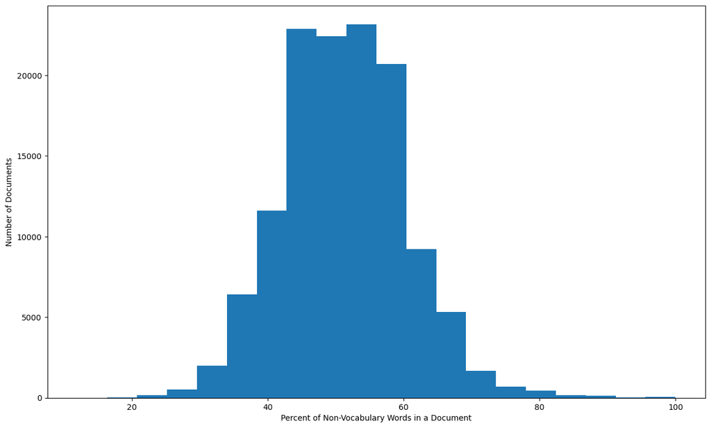

```python
plt.figure(figsize=(15,9))
plt.hist(percents, 20)
plt.ylabel('Number of Documents')
plt.xlabel('Percent of Non-Vocabulary Words in a Document');
```

```python
print(f"There are {count250} top {len(vocab_250)} vocabulary words in the corpus.")
```

```
There are 1925982 top 250 vocabulary words in the corpus.
```

```python
num_classes = 4
model = tf.keras.Sequential([
                              encoder_250
                              ,tf.keras.layers.Embedding(input_dim=len(encoder_250.get_vocabulary())
                              ,output_dim=64
                              ,mask_zero=True)
                              ,tf.keras.layers.Bidirectional(tf.keras.layers.LSTM(64))
                              ,tf.keras.layers.Dense(64, activation='relu')
                              ,tf.keras.layers.Dense(num_classes,activation='softmax')
])
```

```python
model.compile(optimizer=tf.keras.optimizers.Adam(1e-4)
,loss=tf.keras.losses.SparseCategoricalCrossentropy() ,metrics=['accuracy'])
```

```python
history = model.fit(train_dataset
                    ,epochs = 200
                    ,validation_data=validation_dataset
                    ,callbacks=[tf.keras.callbacks.EarlyStopping(monitor='val_accuracy', patience=2)]
                    )
```

```
1782/1782 ━━━━━━━━━━━━━━━━━━━━ 83s 46ms/step - accuracy: 0.4804 - loss: 1.1353 - val_accuracy: 0.7005 - val_loss: 0.7668
1782/1782 ━━━━━━━━━━━━━━━━━━━━ 84s 47ms/step - accuracy: 0.7212 - loss: 0.7203 - val_accuracy: 0.7332 - val_loss: 0.6965
1782/1782 ━━━━━━━━━━━━━━━━━━━━ 85s 48ms/step - accuracy: 0.7460 - loss: 0.6568 - val_accuracy: 0.7585 - val_loss: 0.6305
1782/1782 ━━━━━━━━━━━━━━━━━━━━ 85s 48ms/step - accuracy: 0.7565 - loss: 0.6318 - val_accuracy: 0.7633 - val_loss: 0.6239
1782/1782 ━━━━━━━━━━━━━━━━━━━━ 85s 47ms/step - accuracy: 0.7589 - loss: 0.6226 - val_accuracy: 0.7653 - val_loss: 0.6158
1782/1782 ━━━━━━━━━━━━━━━━━━━━ 85s 48ms/step - accuracy: 0.7612 - loss: 0.6184 - val_accuracy: 0.7635 - val_loss: 0.6155
1782/1782 ━━━━━━━━━━━━━━━━━━━━ 85s 47ms/step - accuracy: 0.7633 - loss: 0.6133 - val_accuracy: 0.7680 - val_loss: 0.6059
1782/1782 ━━━━━━━━━━━━━━━━━━━━ 86s 48ms/step - accuracy: 0.7642 - loss: 0.6091 - val_accuracy: 0.7677 - val_loss: 0.6125
1782/1782 ━━━━━━━━━━━━━━━━━━━━ 85s 48ms/step - accuracy: 0.7664 - loss: 0.6042 - val_accuracy: 0.7648 - val_loss: 0.6100
```

```python
test_loss, test_acc = model.evaluate(test_dataset)

print('Test Loss: {}'.format(test_loss))
print('Test Accuracy: {}'.format(test_acc))
```

```
119/119 ━━━━━━━━━━━━━━━━━━━━ 2s 15ms/step - accuracy: 0.7589 - loss: 0.6206
Test Loss: 0.6232315897941589
Test Accuracy: 0.7549999952316284
```

```python
preds = model.predict(test_dataset)
```

```
119/119 ━━━━━━━━━━━━━━━━━━━━ 1s 11ms/step
```

```python
cm = sns.light_palette((260, 75, 60), input="husl", as_cmap=True)
```

```python
df = pd.DataFrame(preds[0:15], columns = ['World','Sports','Business','Sci/Tech']).T
df.style.format("{:.2%}").background_gradient(cmap=cm)
```

|  | 0 | 1 | 2 | 3 | 4 | 5 | 6 | 7 | 8 | 9 | 10 | 11 | 12 | 13 | 14 |
| --- | --- | --- | --- | --- | --- | --- | --- | --- | --- | --- | --- | --- | --- | --- | --- |
| World | 0.05% | 79.19% | 0.08% | 1.82% | 96.58% | 2.05% | 15.16% | 19.08% | 80.65% | 2.12% | 96.74% | 22.46% | 18.03% | 73.62% | 98.82% |
| Sports | 99.83% | 4.00% | 0.04% | 97.17% | 0.66% | 0.32% | 70.42% | 78.21% | 0.84% | 0.07% | 0.68% | 25.27% | 1.88% | 9.63% | 0.06% |
| Business | 0.05% | 13.41% | 2.27% | 0.47% | 2.01% | 21.06% | 7.52% | 0.56% | 7.53% | 89.74% | 2.37% | 10.10% | 78.32% | 12.42% | 0.91% |
| Sci/Tech | 0.07% | 3.40% | 97.61% | 0.54% | 0.75% | 76.57% | 6.90% | 2.15% | 10.98% | 8.06% | 0.21% | 42.17% | 1.77% | 4.33% | 0.21% |

#### Vocabulary of 500

```python
%%time
encoder_500 = layers.TextVectorization(max_tokens=500)
encoder_500.adapt(text_only_dataset_all)
vocab_500 = np.array(encoder_500.get_vocabulary());
```

```
CPU times: user 2min 49s, sys: 4.11 s, total: 2min 53s
Wall time: 2min 47s
```

```python
vocab_500[:20]
```

```
array(['', '[UNK]', 'the', 'a', 'to', 'of', 'in', 'and', 'on', 'for',
       'that', '39s', 'with', 'its', 'as', 'at', 'is', 'said', 'by', 'it'],
      dtype='<U13')
```

```python
example = "the dog ran after a red ball as it rolled by the hat on the ground."
encoder_500(example)
```

```
<tf.Tensor: shape=(16,), dtype=int64, numpy=
array([  2,   1,   1,  29,   3, 232,   1,  14,  19,   1,  18,   2,   1,
         8,   2,   1])>
```

```python
for word in example.split():
  print(f'"{word}" is {"*not* " if word not in vocab_500  else ""}in the vocabulary.')
```

```
"the" is in the vocabulary.
"dog" is *not* in the vocabulary.
"ran" is *not* in the vocabulary.
"after" is in the vocabulary.
"a" is in the vocabulary.
"red" is in the vocabulary.
"ball" is *not* in the vocabulary.
"as" is in the vocabulary.
"it" is in the vocabulary.
"rolled" is *not* in the vocabulary.
"by" is in the vocabulary.
"the" is in the vocabulary.
"hat" is *not* in the vocabulary.
"on" is in the vocabulary.
"the" is in the vocabulary.
"ground." is *not* in the vocabulary.
```

```python
%%time
doc500_sizes = []
corpus500 = []
count500=0
useless = 0
# stop = 0
percents = []
for example, _ in dataset_all.as_numpy_iterator():
  # stop+=1
  # if stop > 5: break
  enc_example = encoder_500(example)
  num_ones = tf.math.count_nonzero(enc_example==1).numpy()
  percent_ones = round(num_ones*100/len(enc_example))
  # print(f"{percent_ones}%")
  percents.append(percent_ones)

  s = set(list(enc_example.numpy()))
  if s == {1}: useless+=1

  doc500_sizes.append(len(enc_example))
  corpus500+=list(enc_example.numpy())

  count500 += tf.math.count_nonzero(enc_example>1)
```

```
CPU times: user 3min 17s, sys: 2.36 s, total: 3min 19s
Wall time: 3min 15s
```

```python
print(f"Each news article has between {min(doc500_sizes)} and {max(doc500_sizes)} tokens in it.")
```

```
Each news article has between 3 and 173 tokens in it.
```

```python
Counter(percents).most_common(10)
np.unique(percents, return_counts=True)
```

```
(array([  5,   7,   8,   9,  10,  11,  12,  13,  14,  15,  16,  17,  18,
         19,  20,  21,  22,  23,  24,  25,  26,  27,  28,  29,  30,  31,
         32,  33,  34,  35,  36,  37,  38,  39,  40,  41,  42,  43,  44,
         45,  46,  47,  48,  49,  50,  51,  52,  53,  54,  55,  56,  57,
         58,  59,  60,  61,  62,  63,  64,  65,  66,  67,  68,  69,  70,
         71,  72,  73,  74,  75,  76,  77,  78,  79,  80,  81,  82,  83,
         84,  85,  86,  87,  88,  89,  90,  91,  92,  93,  94,  95,  96,
         97, 100]),
 array([   1,    2,    9,    8,    8,   10,   21,   14,   42,   46,   59,
          98,  120,  204,  174,  365,  384,  495,  744,  733, 1150, 1142,
        1371, 2210, 2209, 2553, 3492, 3940, 2593, 3943, 4288, 3427, 6516,
        5252, 4123, 6147, 5897, 5304, 5635, 5049, 4641, 4398, 5752, 1546,
        6892, 1077, 4240, 2508, 2207, 2133, 2070, 1674, 1529, 1237,  910,
         707, 1041,  314,  502,  439,   87,  451,  180,  174,  132,  200,
          64,   97,   47,  112,   44,   37,   41,   24,   72,   15,   30,
          29,    9,   14,   27,    4,   26,   15,   13,    7,    6,    4,
           3,    3,    1,    3,   34]))
```

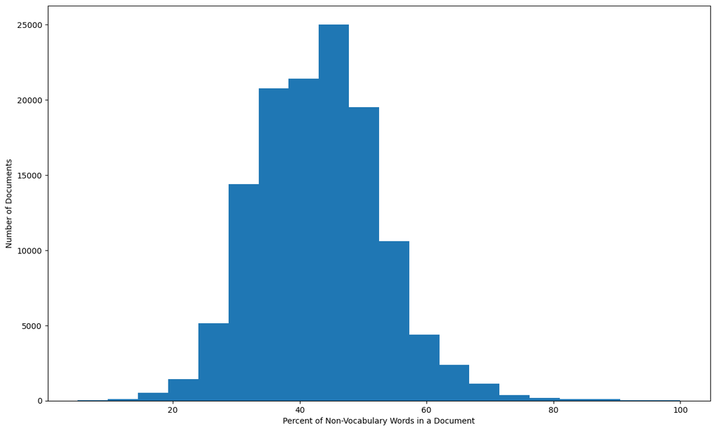

```python
plt.figure(figsize=(15,9))
plt.hist(percents, 20)
plt.ylabel('Number of Documents')
plt.xlabel('Percent of Non-Vocabulary Words in a Document');
```

```python
print(f"There are {count500} top {len(vocab_500)} vocabulary words in the corpus.")
```

```
There are 2245833 top 500 vocabulary words in the corpus.
```

```python
num_classes = 4
model = tf.keras.Sequential([
                              encoder_500
                              ,tf.keras.layers.Embedding(input_dim=len(encoder_500.get_vocabulary())
                              ,output_dim=64
                                # Use masking to handle the variable sequence lengths
                              ,mask_zero=True)
                              ,tf.keras.layers.Bidirectional(tf.keras.layers.LSTM(64))
                              ,tf.keras.layers.Dense(64, activation='relu')
                              ,tf.keras.layers.Dense(num_classes,activation='softmax')   # num_classes = 4
])
```

```python
model.compile(optimizer=tf.keras.optimizers.Adam(1e-4)
              ,loss=tf.keras.losses.SparseCategoricalCrossentropy() # if we set from_logits=True we don not have specify a softmax activation function in the last layer
              ,metrics=['accuracy'])
```

```python
history = model.fit(train_dataset
                    ,epochs = 200
                    ,validation_data=validation_dataset
                    ,callbacks=[tf.keras.callbacks.EarlyStopping(monitor='val_accuracy', patience=2)]
                    )
```

```
1782/1782 ━━━━━━━━━━━━━━━━━━━━ 83s 46ms/step - accuracy: 0.5098 - loss: 1.0982 - val_accuracy: 0.7873 - val_loss: 0.5977
1782/1782 ━━━━━━━━━━━━━━━━━━━━ 83s 47ms/step - accuracy: 0.7944 - loss: 0.5704 - val_accuracy: 0.8133 - val_loss: 0.5238
1782/1782 ━━━━━━━━━━━━━━━━━━━━ 83s 47ms/step - accuracy: 0.8154 - loss: 0.5057 - val_accuracy: 0.8237 - val_loss: 0.4920
1782/1782 ━━━━━━━━━━━━━━━━━━━━ 83s 47ms/step - accuracy: 0.8189 - loss: 0.4884 - val_accuracy: 0.8278 - val_loss: 0.4781
1782/1782 ━━━━━━━━━━━━━━━━━━━━ 84s 47ms/step - accuracy: 0.8214 - loss: 0.4793 - val_accuracy: 0.8298 - val_loss: 0.4741
1782/1782 ━━━━━━━━━━━━━━━━━━━━ 85s 48ms/step - accuracy: 0.8229 - loss: 0.4736 - val_accuracy: 0.8293 - val_loss: 0.4761
1782/1782 ━━━━━━━━━━━━━━━━━━━━ 85s 47ms/step - accuracy: 0.8251 - loss: 0.4677 - val_accuracy: 0.8315 - val_loss: 0.4652
1782/1782 ━━━━━━━━━━━━━━━━━━━━ 86s 48ms/step - accuracy: 0.8258 - loss: 0.4648 - val_accuracy: 0.8320 - val_loss: 0.4682
1782/1782 ━━━━━━━━━━━━━━━━━━━━ 87s 49ms/step - accuracy: 0.8273 - loss: 0.4618 - val_accuracy: 0.8338 - val_loss: 0.4626
1782/1782 ━━━━━━━━━━━━━━━━━━━━ 86s 48ms/step - accuracy: 0.8265 - loss: 0.4587 - val_accuracy: 0.8338 - val_loss: 0.4693
1782/1782 ━━━━━━━━━━━━━━━━━━━━ 84s 47ms/step - accuracy: 0.8290 - loss: 0.4569 - val_accuracy: 0.8325 - val_loss: 0.4642
```

```python
test_loss, test_acc = model.evaluate(test_dataset)

print('Test Loss: {}'.format(test_loss))
print('Test Accuracy: {}'.format(test_acc))
```

```
119/119 ━━━━━━━━━━━━━━━━━━━━ 2s 14ms/step - accuracy: 0.8251 - loss: 0.4709
Test Loss: 0.471632719039917
Test Accuracy: 0.823421061038971
```

```python
preds = model.predict(test_dataset)
```

```
119/119 ━━━━━━━━━━━━━━━━━━━━ 2s 11ms/step
```

```python
cm = sns.light_palette((260, 75, 60), input="husl", as_cmap=True)
```

```python
df = pd.DataFrame(preds[0:15], columns = ['World','Sports','Business','Sci/Tech']).T
df.style.format("{:.2%}").background_gradient(cmap=cm)
```

|  | 0 | 1 | 2 | 3 | 4 | 5 | 6 | 7 | 8 | 9 | 10 | 11 | 12 | 13 | 14 |
| --- | --- | --- | --- | --- | --- | --- | --- | --- | --- | --- | --- | --- | --- | --- | --- |
| World | 0.20% | 99.14% | 0.14% | 1.91% | 99.62% | 0.58% | 1.51% | 14.39% | 92.89% | 2.45% | 99.76% | 0.72% | 0.99% | 51.18% | 99.80% |
| Sports | 99.55% | 0.04% | 0.01% | 97.25% | 0.02% | 0.09% | 98.07% | 84.17% | 0.13% | 0.04% | 0.01% | 15.49% | 0.05% | 18.02% | 0.00% |
| Business | 0.07% | 0.72% | 4.59% | 0.30% | 0.16% | 15.55% | 0.12% | 0.16% | 3.00% | 83.64% | 0.20% | 1.34% | 98.39% | 17.40% | 0.14% |
| Sci/Tech | 0.19% | 0.10% | 95.26% | 0.55% | 0.20% | 83.78% | 0.30% | 1.28% | 3.98% | 13.87% | 0.03% | 82.45% | 0.57% | 13.40% | 0.06% |

#### Vocabulary 1500

```python
%%time
encoder_1500 = layers.TextVectorization(max_tokens=1500)
encoder_1500.adapt(text_only_dataset_all)
vocab_1500 = np.array(encoder_1500.get_vocabulary());
```

```
CPU times: user 2min 53s, sys: 3.4 s, total: 2min 56s
Wall time: 2min 51s
```

```python
vocab_1500[:20]
```

```
array(['', '[UNK]', 'the', 'a', 'to', 'of', 'in', 'and', 'on', 'for',
       'that', '39s', 'with', 'its', 'as', 'at', 'is', 'said', 'by', 'it'],
      dtype='<U19')
```

```python
example = "the dog ran after a red ball as it rolled by the hat on the ground."
encoder_1500(example)
```

```
<tf.Tensor: shape=(16,), dtype=int64, numpy=
array([   2,    1, 1287,   29,    3,  232, 1414,   14,   19,    1,   18,
          2,    1,    8,    2,  999])>
```

```python
for word in example.split():
  print(f'"{word}" is {"*not* " if word not in vocab_1500  else ""}in the vocabulary.')
```

```
"the" is in the vocabulary.
"dog" is *not* in the vocabulary.
"ran" is in the vocabulary.
"after" is in the vocabulary.
"a" is in the vocabulary.
"red" is in the vocabulary.
"ball" is in the vocabulary.
"as" is in the vocabulary.
"it" is in the vocabulary.
"rolled" is *not* in the vocabulary.
"by" is in the vocabulary.
"the" is in the vocabulary.
"hat" is *not* in the vocabulary.
"on" is in the vocabulary.
"the" is in the vocabulary.
"ground." is *not* in the vocabulary.
```

```python
%%time
doc1500_sizes = []
corpus1500 = []
count1500=0
useless = 0
# stop = 0
percents = []
for example, _ in dataset_all.as_numpy_iterator():
  # stop+=1
  # if stop > 5: break
  enc_example = encoder_1500(example)
  num_ones = tf.math.count_nonzero(enc_example==1).numpy()
  percent_ones = round(num_ones*100/len(enc_example))
  # print(f"{percent_ones}%")
  percents.append(percent_ones)

  s = set(list(enc_example.numpy()))
  if s == {1}: useless+=1

  doc1500_sizes.append(len(enc_example))
  corpus1500+=list(enc_example.numpy())

  count1500 += tf.math.count_nonzero(enc_example>1)
```

```
CPU times: user 3min 17s, sys: 2.25 s, total: 3min 19s
Wall time: 3min 16s
```

```python
print(f"Each news article has between {min(doc1500_sizes)} and {max(doc1500_sizes)} tokens in it.")
```

```
Each news article has between 3 and 173 tokens in it.
```

```python
Counter(percents).most_common(10)
np.unique(percents, return_counts=True)
```

```
(array([  0,   2,   3,   4,   5,   6,   7,   8,   9,  10,  11,  12,  13,
         14,  15,  16,  17,  18,  19,  20,  21,  22,  23,  24,  25,  26,
         27,  28,  29,  30,  31,  32,  33,  34,  35,  36,  37,  38,  39,
         40,  41,  42,  43,  44,  45,  46,  47,  48,  49,  50,  51,  52,
         53,  54,  55,  56,  57,  58,  59,  60,  61,  62,  63,  64,  65,
         66,  67,  68,  69,  70,  71,  72,  73,  74,  75,  76,  77,  78,
         79,  80,  81,  82,  83,  84,  85,  86,  87,  88,  89,  90,  91,
         92,  94, 100]),
 array([  69,    2,  101,  164,  154,  229,  347,  559,  593,  757, 1026,
        1722, 1220, 2082, 2256, 2254, 3145, 3196, 4363, 3130, 5053, 4399,
        4583, 5721, 4645, 5682, 4651, 4496, 6009, 4865, 4563, 5430, 5168,
        2479, 3989, 3240, 2274, 3801, 2523, 1854, 2243, 1876, 1605, 1386,
        1110,  912,  826,  940,  108, 1182,   71,  471,  327,  209,  208,
         209,  171,  127,   83,  107,   36,  113,   29,   66,   50,    3,
          63,   10,   25,   17,   33,    5,   15,    5,   35,    8,    4,
          17,    3,   20,    6,    6,   15,    3,    5,    8,    2,    3,
           4,    2,    3,    1,    1,   19]))
```

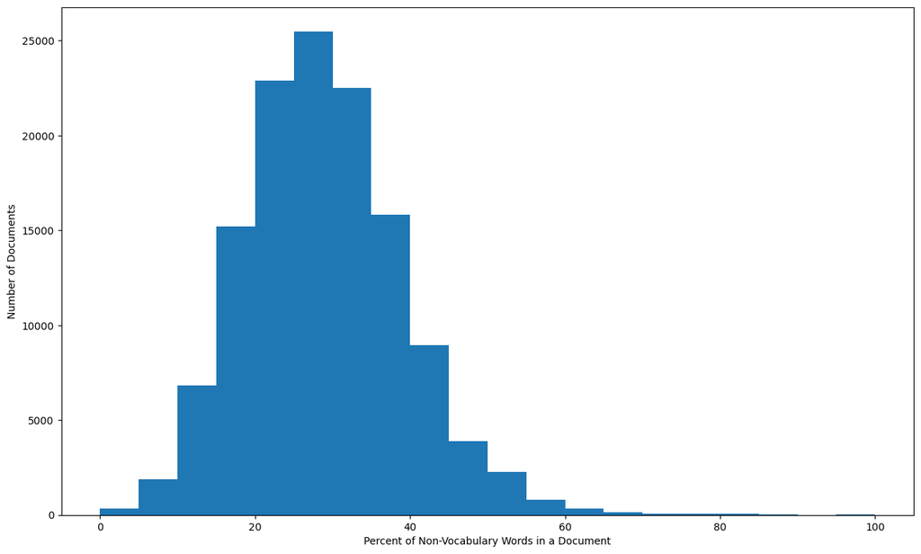

```python
plt.figure(figsize=(15,9))
plt.hist(percents, 20)
plt.ylabel('Number of Documents')
plt.xlabel('Percent of Non-Vocabulary Words in a Document');
```

```python
print(f"There are {count1500} top {len(vocab_1500)} vocabulary words in the corpus.")
```

```
There are 2810751 top 1500 vocabulary words in the corpus.
```

```python
num_classes = 4
model = tf.keras.Sequential([
                              encoder_1500
                              ,tf.keras.layers.Embedding(input_dim=len(encoder_1500.get_vocabulary())
                              ,output_dim=64
                                # Use masking to handle the variable sequence lengths
                              ,mask_zero=True)
                              ,tf.keras.layers.Bidirectional(tf.keras.layers.LSTM(64))
                              ,tf.keras.layers.Dense(64, activation='relu')
                              ,tf.keras.layers.Dense(num_classes,activation='softmax')   # num_classes = 4
])
```

```python
model.compile(optimizer=tf.keras.optimizers.Adam(1e-4)
              ,loss=tf.keras.losses.SparseCategoricalCrossentropy() # if we set from_logits=True we don not have specify a softmax activation function in the last layer
              ,metrics=['accuracy'])
```

```python
history = model.fit(train_dataset
                    ,epochs = 200
                    ,validation_data=validation_dataset
                    ,callbacks=[tf.keras.callbacks.EarlyStopping(monitor='val_accuracy', patience=2)]
                    )
```

```
1782/1782 ━━━━━━━━━━━━━━━━━━━━ 83s 46ms/step - accuracy: 0.6131 - loss: 0.9451 - val_accuracy: 0.8578 - val_loss: 0.4124
1782/1782 ━━━━━━━━━━━━━━━━━━━━ 85s 48ms/step - accuracy: 0.8603 - loss: 0.3972 - val_accuracy: 0.8688 - val_loss: 0.3720
1782/1782 ━━━━━━━━━━━━━━━━━━━━ 103s 58ms/step - accuracy: 0.8702 - loss: 0.3609 - val_accuracy: 0.8720 - val_loss: 0.3611
1782/1782 ━━━━━━━━━━━━━━━━━━━━ 94s 53ms/step - accuracy: 0.8741 - loss: 0.3479 - val_accuracy: 0.8722 - val_loss: 0.3556
1782/1782 ━━━━━━━━━━━━━━━━━━━━ 87s 49ms/step - accuracy: 0.8770 - loss: 0.3410 - val_accuracy: 0.8747 - val_loss: 0.3520
1782/1782 ━━━━━━━━━━━━━━━━━━━━ 89s 50ms/step - accuracy: 0.8784 - loss: 0.3348 - val_accuracy: 0.8677 - val_loss: 0.3593
1782/1782 ━━━━━━━━━━━━━━━━━━━━ 88s 49ms/step - accuracy: 0.8799 - loss: 0.3305 - val_accuracy: 0.8670 - val_loss: 0.3555
```

```python
test_loss, test_acc = model.evaluate(test_dataset)

print('Test Loss: {}'.format(test_loss))
print('Test Accuracy: {}'.format(test_acc))
```

```
119/119 ━━━━━━━━━━━━━━━━━━━━ 2s 15ms/step - accuracy: 0.8750 - loss: 0.3574
Test Loss: 0.36376407742500305
Test Accuracy: 0.8722368478775024
```

```python
preds = model.predict(test_dataset)
```

```
119/119 ━━━━━━━━━━━━━━━━━━━━ 2s 12ms/step
```

```python
cm = sns.light_palette((260, 75, 60), input="husl", as_cmap=True)
```

```python
df = pd.DataFrame(preds[0:15], columns = ['World','Sports','Business','Sci/Tech']).T
df.style.format("{:.2%}").background_gradient(cmap=cm)
```

|  | 0 | 1 | 2 | 3 | 4 | 5 | 6 | 7 | 8 | 9 | 10 | 11 | 12 | 13 | 14 |
| --- | --- | --- | --- | --- | --- | --- | --- | --- | --- | --- | --- | --- | --- | --- | --- |
| World | 0.44% | 99.93% | 0.28% | 2.40% | 99.86% | 0.62% | 0.92% | 39.38% | 96.47% | 4.24% | 99.98% | 1.21% | 0.77% | 92.01% | 99.90% |
| Sports | 99.39% | 0.00% | 0.00% | 97.37% | 0.00% | 0.08% | 98.54% | 54.05% | 0.01% | 0.12% | 0.00% | 0.51% | 0.02% | 1.83% | 0.00% |
| Business | 0.04% | 0.05% | 2.99% | 0.15% | 0.09% | 12.88% | 0.07% | 0.50% | 0.89% | 89.36% | 0.01% | 1.01% | 98.82% | 2.07% | 0.03% |
| Sci/Tech | 0.13% | 0.02% | 96.73% | 0.08% | 0.05% | 86.43% | 0.46% | 6.08% | 2.64% | 6.29% | 0.01% | 97.27% | 0.39% | 4.09% | 0.07% |

### (b) Editing the Vocabulary: Try unedited most frequent words, VS edit the list by deleting the most frequent words such as articles, ‘the’, ‘a’, etc.

.

```python
VOCAB_SIZE=1000
encoder = layers.TextVectorization(
    max_tokens=VOCAB_SIZE)
encoder.adapt(text_only_train_ds)
```

```
2024-11-03 16:14:47.203151: I tensorflow/core/framework/local_rendezvous.cc:404] Local rendezvous is aborting with status: OUT_OF_RANGE: End of sequence
```

```python
vocab = np.array(encoder.get_vocabulary())
len(vocab)
```

```
1000
```

```python
vocab.shape
```

```
(1000,)
```

```python
print(stopwords.words('english'))
```

```
['i', 'me', 'my', 'myself', 'we', 'our', 'ours', 'ourselves', 'you', "you're", "you've", "you'll", "you'd", 'your', 'yours', 'yourself', 'yourselves', 'he', 'him', 'his', 'himself', 'she', "she's", 'her', 'hers', 'herself', 'it', "it's", 'its', 'itself', 'they', 'them', 'their', 'theirs', 'themselve…
```

```python
stop_words = set(stopwords.words('english'))
```

```python
vocab_wo_stop = [word for word in vocab if not word in stop_words]
```

```python
len(vocab_wo_stop)
```

```
898
```

```python
len(vocab)
```

```
1000
```

```python
vocab[:20]
```

```
array(['', '[UNK]', 'the', 'a', 'to', 'of', 'in', 'and', 'on', 'for',
       'that', '39s', 'with', 'its', 'as', 'at', 'is', 'said', 'by', 'it'],
      dtype='<U14')
```

```python
# See vocabulary without the common "stop-words"
vocab_wo_stop[:20]
```

```
['',
 '[UNK]',
 '39s',
 'said',
 'new',
 'us',
 'reuters',
 'ap',
 'two',
 'first',
 'monday',
 'wednesday',
 'tuesday',
 'thursday',
 'company',
 'friday',
 'inc',
 'one',
 'world',
 'yesterday']
```

```python
VOCAB_SIZE=1000
encoder_wo_stop = layers.TextVectorization(
    max_tokens=VOCAB_SIZE, vocabulary = vocab_wo_stop)
encoder.adapt(text_only_train_ds)
```

```python
num_classes = 4
model = tf.keras.Sequential([
                              encoder
                              ,tf.keras.layers.Embedding(input_dim=len(encoder.get_vocabulary())
                              ,output_dim=64
                              ,mask_zero=True)
                              ,tf.keras.layers.Bidirectional(tf.keras.layers.LSTM(64))
                              ,tf.keras.layers.Dense(64, activation='relu')
                              ,tf.keras.layers.Dense(num_classes,activation='softmax')   # num_classes = 4
])
```

```python
model.compile(optimizer=tf.keras.optimizers.Adam(1e-4)
              ,loss=tf.keras.losses.SparseCategoricalCrossentropy() # if we set from_logits=True we don not have specify a softmax activation function in the last layer
              ,metrics=['accuracy'])
```

```python
history = model.fit(train_dataset
                    ,epochs = 200
                    ,validation_data=validation_dataset
                    ,callbacks=[tf.keras.callbacks.EarlyStopping(monitor='val_accuracy', patience=2)]
                    )
```

```
1782/1782 ━━━━━━━━━━━━━━━━━━━━ 85s 47ms/step - accuracy: 0.5798 - loss: 0.9800 - val_accuracy: 0.8123 - val_loss: 0.5292
1782/1782 ━━━━━━━━━━━━━━━━━━━━ 91s 51ms/step - accuracy: 0.8363 - loss: 0.4587 - val_accuracy: 0.8555 - val_loss: 0.4169
1782/1782 ━━━━━━━━━━━━━━━━━━━━ 99s 55ms/step - accuracy: 0.8536 - loss: 0.4092 - val_accuracy: 0.8548 - val_loss: 0.4079
1782/1782 ━━━━━━━━━━━━━━━━━━━━ 88s 49ms/step - accuracy: 0.8570 - loss: 0.3963 - val_accuracy: 0.8605 - val_loss: 0.3912
1782/1782 ━━━━━━━━━━━━━━━━━━━━ 89s 50ms/step - accuracy: 0.8589 - loss: 0.3888 - val_accuracy: 0.8560 - val_loss: 0.4010
1782/1782 ━━━━━━━━━━━━━━━━━━━━ 93s 52ms/step - accuracy: 0.8613 - loss: 0.3819 - val_accuracy: 0.8637 - val_loss: 0.3870
1782/1782 ━━━━━━━━━━━━━━━━━━━━ 90s 50ms/step - accuracy: 0.8626 - loss: 0.3781 - val_accuracy: 0.8613 - val_loss: 0.3871
1782/1782 ━━━━━━━━━━━━━━━━━━━━ 92s 52ms/step - accuracy: 0.8636 - loss: 0.3742 - val_accuracy: 0.8600 - val_loss: 0.3955
```

```python
test_loss, test_acc = model.evaluate(test_dataset)

print('Test Loss: {}'.format(test_loss))
print('Test Accuracy: {}'.format(test_acc))
```

```
119/119 ━━━━━━━━━━━━━━━━━━━━ 2s 16ms/step - accuracy: 0.8553 - loss: 0.4055
Test Loss: 0.4089396297931671
Test Accuracy: 0.8534210324287415
```

```python
preds = model.predict(test_dataset)
```

```
119/119 ━━━━━━━━━━━━━━━━━━━━ 2s 13ms/step
```

```python
cm = sns.light_palette((260, 75, 60), input="husl", as_cmap=True)
```

```python
df = pd.DataFrame(preds[0:15], columns = ['World','Sports','Business','Sci/Tech']).T
df.style.format("{:.2%}").background_gradient(cmap=cm)
```

|  | 0 | 1 | 2 | 3 | 4 | 5 | 6 | 7 | 8 | 9 | 10 | 11 | 12 | 13 | 14 |
| --- | --- | --- | --- | --- | --- | --- | --- | --- | --- | --- | --- | --- | --- | --- | --- |
| World | 0.27% | 99.89% | 0.04% | 1.09% | 99.75% | 0.50% | 1.13% | 18.82% | 94.86% | 2.05% | 99.94% | 0.31% | 0.69% | 96.24% | 99.87% |
| Sports | 99.65% | 0.01% | 0.00% | 98.74% | 0.01% | 0.13% | 98.53% | 77.59% | 0.71% | 0.06% | 0.00% | 0.47% | 0.04% | 0.47% | 0.00% |
| Business | 0.05% | 0.07% | 4.05% | 0.07% | 0.09% | 18.96% | 0.08% | 0.30% | 1.28% | 89.33% | 0.04% | 1.74% | 98.77% | 1.41% | 0.05% |
| Sci/Tech | 0.03% | 0.04% | 95.90% | 0.11% | 0.15% | 80.40% | 0.26% | 3.29% | 3.15% | 8.55% | 0.01% | 97.48% | 0.50% | 1.88% | 0.08% |

### (c) Output sequence length: Use the default VS set it to a fixed number

```python
%%time
encoder_1000 = layers.TextVectorization(max_tokens=1000, output_sequence_length=40)
encoder_1000.adapt(text_only_dataset_all)
vocab_1000 = np.array(encoder_1000.get_vocabulary());
```

```
CPU times: user 2min 58s, sys: 3.18 s, total: 3min 2s
Wall time: 2min 57s
```

```python
vocab_1000[:20]
```

```
array(['', '[UNK]', 'the', 'a', 'to', 'of', 'in', 'and', 'on', 'for',
       'that', '39s', 'with', 'its', 'as', 'at', 'is', 'said', 'by', 'it'],
      dtype='<U14')
```

```python
example = "the dog ran after a red ball as it rolled by the hat on the ground."
encoder_1000(example)
```

```
<tf.Tensor: shape=(40,), dtype=int64, numpy=
array([  2,   1,   1,  29,   3, 232,   1,  14,  19,   1,  18,   2,   1,
         8,   2, 999,   0,   0,   0,   0,   0,   0,   0,   0,   0,   0,
         0,   0,   0,   0,   0,   0,   0,   0,   0,   0,   0,   0,   0,
         0])>
```

```python
for word in example.split():
  print(f'"{word}" is {"*not* " if word not in vocab_1000  else ""}in the vocabulary.')
```

```
"the" is in the vocabulary.
"dog" is *not* in the vocabulary.
"ran" is *not* in the vocabulary.
"after" is in the vocabulary.
"a" is in the vocabulary.
"red" is in the vocabulary.
"ball" is *not* in the vocabulary.
"as" is in the vocabulary.
"it" is in the vocabulary.
"rolled" is *not* in the vocabulary.
"by" is in the vocabulary.
"the" is in the vocabulary.
"hat" is *not* in the vocabulary.
"on" is in the vocabulary.
"the" is in the vocabulary.
"ground." is *not* in the vocabulary.
```

```python
num_classes = 4
model = tf.keras.Sequential([
                              encoder_1000
                              ,tf.keras.layers.Embedding(input_dim=len(encoder_1000.get_vocabulary())
                              ,output_dim=64
                              ,mask_zero=True)
                              ,tf.keras.layers.Bidirectional(tf.keras.layers.LSTM(64))
                              ,tf.keras.layers.Dense(64, activation='relu')
                              ,tf.keras.layers.Dense(num_classes,activation='softmax')   # num_classes = 4
])
```

```python
model.compile(optimizer=tf.keras.optimizers.Adam(1e-4)
              ,loss=tf.keras.losses.SparseCategoricalCrossentropy()
              ,metrics=['accuracy'])
```

```python
history = model.fit(train_dataset
                    ,epochs = 200
                    ,validation_data=validation_dataset
                    ,callbacks=[tf.keras.callbacks.EarlyStopping(monitor='val_accuracy', patience=2)]
                    )
```

```
1782/1782 ━━━━━━━━━━━━━━━━━━━━ 59s 32ms/step - accuracy: 0.5961 - loss: 0.9538 - val_accuracy: 0.8258 - val_loss: 0.4952
1782/1782 ━━━━━━━━━━━━━━━━━━━━ 58s 33ms/step - accuracy: 0.8309 - loss: 0.4681 - val_accuracy: 0.8410 - val_loss: 0.4481
1782/1782 ━━━━━━━━━━━━━━━━━━━━ 58s 33ms/step - accuracy: 0.8437 - loss: 0.4294 - val_accuracy: 0.8472 - val_loss: 0.4217
1782/1782 ━━━━━━━━━━━━━━━━━━━━ 59s 33ms/step - accuracy: 0.8529 - loss: 0.4071 - val_accuracy: 0.8523 - val_loss: 0.4075
1782/1782 ━━━━━━━━━━━━━━━━━━━━ 298s 167ms/step - accuracy: 0.8550 - loss: 0.3971 - val_accuracy: 0.8453 - val_loss: 0.4226
1782/1782 ━━━━━━━━━━━━━━━━━━━━ 53s 30ms/step - accuracy: 0.8577 - loss: 0.3890 - val_accuracy: 0.8550 - val_loss: 0.3921
1782/1782 ━━━━━━━━━━━━━━━━━━━━ 55s 31ms/step - accuracy: 0.8589 - loss: 0.3863 - val_accuracy: 0.8565 - val_loss: 0.3950
1782/1782 ━━━━━━━━━━━━━━━━━━━━ 56s 31ms/step - accuracy: 0.8609 - loss: 0.3805 - val_accuracy: 0.8588 - val_loss: 0.3899
1782/1782 ━━━━━━━━━━━━━━━━━━━━ 56s 31ms/step - accuracy: 0.8627 - loss: 0.3768 - val_accuracy: 0.8593 - val_loss: 0.3970
1782/1782 ━━━━━━━━━━━━━━━━━━━━ 63s 35ms/step - accuracy: 0.8628 - loss: 0.3751 - val_accuracy: 0.8563 - val_loss: 0.3946
1782/1782 ━━━━━━━━━━━━━━━━━━━━ 64s 36ms/step - accuracy: 0.8632 - loss: 0.3724 - val_accuracy: 0.8605 - val_loss: 0.3883
1782/1782 ━━━━━━━━━━━━━━━━━━━━ 63s 35ms/step - accuracy: 0.8644 - loss: 0.3679 - val_accuracy: 0.8593 - val_loss: 0.4022
1782/1782 ━━━━━━━━━━━━━━━━━━━━ 62s 35ms/step - accuracy: 0.8653 - loss: 0.3658 - val_accuracy: 0.8628 - val_loss: 0.3800
1782/1782 ━━━━━━━━━━━━━━━━━━━━ 64s 36ms/step - accuracy: 0.8665 - loss: 0.3621 - val_accuracy: 0.8630 - val_loss: 0.3792
1782/1782 ━━━━━━━━━━━━━━━━━━━━ 64s 36ms/step - accuracy: 0.8685 - loss: 0.3569 - val_accuracy: 0.8618 - val_loss: 0.3801
1782/1782 ━━━━━━━━━━━━━━━━━━━━ 64s 36ms/step - accuracy: 0.8685 - loss: 0.3565 - val_accuracy: 0.8617 - val_loss: 0.3829
```

```python
test_loss, test_acc = model.evaluate(test_dataset)

print('Test Loss: {}'.format(test_loss))
print('Test Accuracy: {}'.format(test_acc))
```

```
119/119 ━━━━━━━━━━━━━━━━━━━━ 1s 11ms/step - accuracy: 0.8561 - loss: 0.3928
Test Loss: 0.39761483669281006
Test Accuracy: 0.8536841869354248
```

```python
results = {}
```

# Experiments B: RNN

##### Try several experiments by tweaking (i) architecture (ii) Bidirectional/unidirectional & other hyper parameters, including regularization.

### Bidirectional Simple RNN

```python
num_classes = 4
model = tf.keras.Sequential([
                              encoder
                              ,tf.keras.layers.Embedding(input_dim=len(encoder.get_vocabulary())
                              ,output_dim=64
                              ,mask_zero=True)
                              ,tf.keras.layers.Bidirectional(tf.keras.layers.SimpleRNN(64))
                              ,tf.keras.layers.Dense(64, activation='relu')
                              ,tf.keras.layers.Dense(num_classes,activation='softmax')
])
results["Experiments B: RNN 1"] = {}
results["Experiments B: RNN 1"]["Architecture"] = "Bidirectional Simple RNN"
```

#### Compile Model

```python
model.compile(optimizer=tf.keras.optimizers.Adam(1e-4)
              ,loss=tf.keras.losses.SparseCategoricalCrossentropy()
              ,metrics=['accuracy'])
```

```python
print([layer.supports_masking for layer in model.layers])
```

```
[False, True, True, True, True]
```

#### Train model

```python
# Start time
start_time = time.time()

history = model.fit(train_dataset
                    ,epochs = 200
                    ,validation_data=validation_dataset
                    ,callbacks=[tf.keras.callbacks.EarlyStopping(monitor='val_accuracy', patience=2)]
                    )

# End time
end_time = time.time()

# Calculate and print the time taken
elapsed_time = end_time - start_time
print(f"Time taken to train Model: {elapsed_time:.2f} seconds")
results["Experiments B: RNN 1"]["Train Time"] = str(round(elapsed_time, 2)) + ' seconds'
```

```
1782/1782 ━━━━━━━━━━━━━━━━━━━━ 41s 23ms/step - accuracy: 0.5672 - loss: 0.9655 - val_accuracy: 0.8360 - val_loss: 0.4760
1782/1782 ━━━━━━━━━━━━━━━━━━━━ 41s 23ms/step - accuracy: 0.8328 - loss: 0.4648 - val_accuracy: 0.8515 - val_loss: 0.4198
1782/1782 ━━━━━━━━━━━━━━━━━━━━ 41s 23ms/step - accuracy: 0.8506 - loss: 0.4136 - val_accuracy: 0.8565 - val_loss: 0.4104
1782/1782 ━━━━━━━━━━━━━━━━━━━━ 41s 23ms/step - accuracy: 0.8564 - loss: 0.3925 - val_accuracy: 0.8502 - val_loss: 0.4124
1782/1782 ━━━━━━━━━━━━━━━━━━━━ 41s 23ms/step - accuracy: 0.8610 - loss: 0.3812 - val_accuracy: 0.8623 - val_loss: 0.3867
1782/1782 ━━━━━━━━━━━━━━━━━━━━ 40s 23ms/step - accuracy: 0.8654 - loss: 0.3710 - val_accuracy: 0.8637 - val_loss: 0.3885
1782/1782 ━━━━━━━━━━━━━━━━━━━━ 40s 23ms/step - accuracy: 0.8662 - loss: 0.3650 - val_accuracy: 0.8652 - val_loss: 0.3850
1782/1782 ━━━━━━━━━━━━━━━━━━━━ 41s 23ms/step - accuracy: 0.8683 - loss: 0.3585 - val_accuracy: 0.8600 - val_loss: 0.3921
1782/1782 ━━━━━━━━━━━━━━━━━━━━ 41s 23ms/step - accuracy: 0.8719 - loss: 0.3487 - val_accuracy: 0.8648 - val_loss: 0.3830
Time taken to train Model: 367.28 seconds
```

```python
train_loss = history.history['loss'][-1]  # Training loss from the last epoch
train_accuracy = history.history['accuracy'][-1]  # Training accuracy from the last epoch
val_loss = history.history['val_loss'][-1]  # Validation loss from the last epoch
val_accuracy = history.history['val_accuracy'][-1]  # Validation accuracy from the last epoch

test_loss, test_acc = model.evaluate(test_dataset)
print(f"Test Loss: {test_loss:.3f}, Test Accuracy: {test_acc:.3f}")
print(f"Training Loss: {train_loss:.3f}, Training Accuracy: {train_accuracy:.3f}")
print(f"Validation Loss: {val_loss:.3f}, Validation Accuracy: {val_accuracy:.3f}")

results["Experiments B: RNN 1"]["Test Accuracy"] = round(test_acc,3)
results["Experiments B: RNN 1"]["Test Loss"] = round(test_loss,3)
results["Experiments B: RNN 1"]["Train Accuracy"] = round(train_accuracy,3)
results["Experiments B: RNN 1"]["Train Loss"] = round(train_loss,3)
results["Experiments B: RNN 1"]["Validation Accuracy"] = round(val_accuracy,3)
results["Experiments B: RNN 1"]["Validation Loss"] = round(val_loss,3)
```

```
119/119 ━━━━━━━━━━━━━━━━━━━━ 1s 6ms/step - accuracy: 0.8584 - loss: 0.3868
Test Loss: 0.392, Test Accuracy: 0.857
Training Loss: 0.351, Training Accuracy: 0.872
Validation Loss: 0.383, Validation Accuracy: 0.865
```

#### Performance Metrics

```python
history_dict = history.history
history_dict.keys()
```

```
dict_keys(['accuracy', 'loss', 'val_accuracy', 'val_loss'])
```

```python
history_df=pd.DataFrame(history_dict)
history_df.tail(10).round(3)
```

|  | accuracy | loss | val_accuracy | val_loss |
| --- | --- | --- | --- | --- |
| 0 | 0.711 | 0.713 | 0.836 | 0.476 |
| 1 | 0.836 | 0.456 | 0.851 | 0.420 |
| 2 | 0.851 | 0.412 | 0.857 | 0.410 |
| 3 | 0.857 | 0.393 | 0.850 | 0.412 |
| 4 | 0.861 | 0.382 | 0.862 | 0.387 |
| 5 | 0.865 | 0.373 | 0.864 | 0.389 |
| 6 | 0.867 | 0.366 | 0.865 | 0.385 |
| 7 | 0.869 | 0.359 | 0.860 | 0.392 |
| 8 | 0.872 | 0.351 | 0.865 | 0.383 |

```python
losses = history.history['loss']
accs = history.history['accuracy']
val_losses = history.history['val_loss']
val_accs = history.history['val_accuracy']
epochs = len(losses)
```

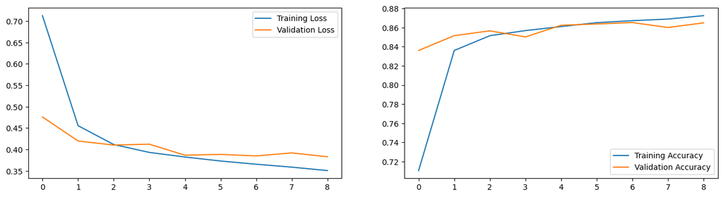

```python
plt.figure(figsize=(16, 4))
for i, metrics in enumerate(zip([losses, accs], [val_losses, val_accs], ['Loss', 'Accuracy'])):
    plt.subplot(1, 2, i + 1)
    plt.plot(range(epochs), metrics[0], label='Training {}'.format(metrics[2]))
    plt.plot(range(epochs), metrics[1], label='Validation {}'.format(metrics[2]))
    plt.legend()
plt.show()
```

#### Confusion Matrix

```python
preds = model.predict(test_dataset)
```

```
119/119 ━━━━━━━━━━━━━━━━━━━━ 1s 6ms/step
```

```python
cm = sns.light_palette((260, 75, 60), input="husl", as_cmap=True)
```

```python
df = pd.DataFrame(preds[0:15], columns = ['World','Sports','Business','Sci/Tech']).T
df.style.format("{:.2%}").background_gradient(cmap=cm)
```

|  | 0 | 1 | 2 | 3 | 4 | 5 | 6 | 7 | 8 | 9 | 10 | 11 | 12 | 13 | 14 |
| --- | --- | --- | --- | --- | --- | --- | --- | --- | --- | --- | --- | --- | --- | --- | --- |
| World | 0.10% | 99.81% | 0.26% | 0.76% | 99.84% | 0.57% | 0.29% | 14.35% | 93.53% | 1.76% | 99.84% | 0.06% | 0.29% | 90.94% | 99.88% |
| Sports | 99.86% | 0.01% | 0.02% | 98.97% | 0.01% | 0.59% | 99.02% | 81.98% | 0.08% | 0.04% | 0.01% | 0.20% | 0.01% | 1.11% | 0.00% |
| Business | 0.02% | 0.11% | 2.15% | 0.11% | 0.06% | 12.66% | 0.17% | 0.33% | 0.83% | 87.39% | 0.07% | 0.60% | 99.08% | 3.50% | 0.10% |
| Sci/Tech | 0.02% | 0.07% | 97.58% | 0.16% | 0.10% | 86.18% | 0.52% | 3.35% | 5.56% | 10.81% | 0.08% | 99.14% | 0.61% | 4.44% | 0.03% |

### Unidirectional Single Layer Simple RNN

```python
num_classes = 4
model = tf.keras.Sequential([
                              encoder
                              ,tf.keras.layers.Embedding(input_dim=len(encoder.get_vocabulary())
                              ,output_dim=64
                              ,mask_zero=True)
                              ,tf.keras.layers.SimpleRNN(64)
                              ,tf.keras.layers.Dense(64, activation='relu')
                              ,tf.keras.layers.Dense(num_classes,activation='softmax')
])
results["Experiments B: RNN 2"] = {}
results["Experiments B: RNN 2"]["Architecture"] = "Unidirectional Single Layer Simple RNN"
```

#### Compile Model

```python
model.compile(optimizer=tf.keras.optimizers.Adam(1e-4)
              ,loss=tf.keras.losses.SparseCategoricalCrossentropy() # if we set from_logits=True we don not have specify a softmax activation function in the last layer
              ,metrics=['accuracy'])
```

#### Train Model

```python
# Start time
start_time = time.time()

history = model.fit(train_dataset
                    ,epochs = 200
                    ,validation_data=validation_dataset
                    ,callbacks=[tf.keras.callbacks.EarlyStopping(monitor='val_accuracy', patience=2)]
                    )


# End time
end_time = time.time()

# Calculate and print the time taken
elapsed_time = end_time - start_time
print(f"Time taken to train Model: {elapsed_time:.2f} seconds")
results["Experiments B: RNN 2"]["Train Time"] = str(round(elapsed_time, 2)) + ' seconds'
```

```
1782/1782 ━━━━━━━━━━━━━━━━━━━━ 22s 11ms/step - accuracy: 0.5164 - loss: 1.0507 - val_accuracy: 0.8218 - val_loss: 0.5069
1782/1782 ━━━━━━━━━━━━━━━━━━━━ 20s 11ms/step - accuracy: 0.8231 - loss: 0.4935 - val_accuracy: 0.8352 - val_loss: 0.4651
1782/1782 ━━━━━━━━━━━━━━━━━━━━ 20s 11ms/step - accuracy: 0.8342 - loss: 0.4593 - val_accuracy: 0.8355 - val_loss: 0.4601
1782/1782 ━━━━━━━━━━━━━━━━━━━━ 20s 11ms/step - accuracy: 0.8366 - loss: 0.4497 - val_accuracy: 0.8358 - val_loss: 0.4679
1782/1782 ━━━━━━━━━━━━━━━━━━━━ 20s 11ms/step - accuracy: 0.8410 - loss: 0.4402 - val_accuracy: 0.8355 - val_loss: 0.4587
1782/1782 ━━━━━━━━━━━━━━━━━━━━ 20s 11ms/step - accuracy: 0.8432 - loss: 0.4337 - val_accuracy: 0.8377 - val_loss: 0.4509
1782/1782 ━━━━━━━━━━━━━━━━━━━━ 20s 11ms/step - accuracy: 0.8460 - loss: 0.4254 - val_accuracy: 0.8505 - val_loss: 0.4286
1782/1782 ━━━━━━━━━━━━━━━━━━━━ 20s 11ms/step - accuracy: 0.8544 - loss: 0.4054 - val_accuracy: 0.8485 - val_loss: 0.4213
1782/1782 ━━━━━━━━━━━━━━━━━━━━ 20s 11ms/step - accuracy: 0.8591 - loss: 0.3914 - val_accuracy: 0.8545 - val_loss: 0.4036
1782/1782 ━━━━━━━━━━━━━━━━━━━━ 20s 11ms/step - accuracy: 0.8625 - loss: 0.3805 - val_accuracy: 0.8547 - val_loss: 0.4004
1782/1782 ━━━━━━━━━━━━━━━━━━━━ 20s 11ms/step - accuracy: 0.8664 - loss: 0.3678 - val_accuracy: 0.8558 - val_loss: 0.4008
1782/1782 ━━━━━━━━━━━━━━━━━━━━ 20s 11ms/step - accuracy: 0.8697 - loss: 0.3614 - val_accuracy: 0.8517 - val_loss: 0.4146
1782/1782 ━━━━━━━━━━━━━━━━━━━━ 20s 11ms/step - accuracy: 0.8732 - loss: 0.3517 - val_accuracy: 0.8525 - val_loss: 0.4162
Time taken to train Model: 266.30 seconds
```

```python
train_loss = history.history['loss'][-1]  # Training loss from the last epoch
train_accuracy = history.history['accuracy'][-1]  # Training accuracy from the last epoch
val_loss = history.history['val_loss'][-1]  # Validation loss from the last epoch
val_accuracy = history.history['val_accuracy'][-1]  # Validation accuracy from the last epoch

test_loss, test_acc = model.evaluate(test_dataset)
print(f"Test Loss: {test_loss:.3f}, Test Accuracy: {test_acc:.3f}")
print(f"Training Loss: {train_loss:.3f}, Training Accuracy: {train_accuracy:.3f}")
print(f"Validation Loss: {val_loss:.3f}, Validation Accuracy: {val_accuracy:.3f}")

results["Experiments B: RNN 2"]["Test Accuracy"] = round(test_acc,3)
results["Experiments B: RNN 2"]["Test Loss"] = round(test_loss,3)
results["Experiments B: RNN 2"]["Train Accuracy"] = round(train_accuracy,3)
results["Experiments B: RNN 2"]["Train Loss"] = round(train_loss,3)
results["Experiments B: RNN 2"]["Validation Accuracy"] = round(val_accuracy,3)
results["Experiments B: RNN 2"]["Validation Loss"] = round(val_loss,3)
```

```
119/119 ━━━━━━━━━━━━━━━━━━━━ 0s 3ms/step - accuracy: 0.8453 - loss: 0.4278
Test Loss: 0.433, Test Accuracy: 0.845
Training Loss: 0.354, Training Accuracy: 0.873
Validation Loss: 0.416, Validation Accuracy: 0.853
```

#### Performance Metrics

```python
history_dict = history.history
history_dict.keys()
```

```
dict_keys(['accuracy', 'loss', 'val_accuracy', 'val_loss'])
```

```python
history_df=pd.DataFrame(history_dict)
history_df.tail(10).round(3)
```

|  | accuracy | loss | val_accuracy | val_loss |
| --- | --- | --- | --- | --- |
| 3 | 0.838 | 0.450 | 0.836 | 0.468 |
| 4 | 0.841 | 0.444 | 0.836 | 0.459 |
| 5 | 0.843 | 0.436 | 0.838 | 0.451 |
| 6 | 0.847 | 0.425 | 0.850 | 0.429 |
| 7 | 0.854 | 0.407 | 0.849 | 0.421 |
| 8 | 0.860 | 0.391 | 0.854 | 0.404 |
| 9 | 0.863 | 0.380 | 0.855 | 0.400 |
| 10 | 0.866 | 0.371 | 0.856 | 0.401 |
| 11 | 0.870 | 0.362 | 0.852 | 0.415 |
| 12 | 0.873 | 0.354 | 0.853 | 0.416 |

```python
losses = history.history['loss']
accs = history.history['accuracy']
val_losses = history.history['val_loss']
val_accs = history.history['val_accuracy']
epochs = len(losses)
```

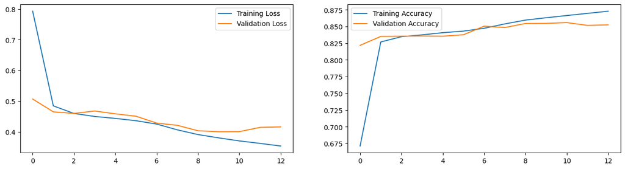

```python
plt.figure(figsize=(16, 4))
for i, metrics in enumerate(zip([losses, accs], [val_losses, val_accs], ['Loss', 'Accuracy'])):
    plt.subplot(1, 2, i + 1)
    plt.plot(range(epochs), metrics[0], label='Training {}'.format(metrics[2]))
    plt.plot(range(epochs), metrics[1], label='Validation {}'.format(metrics[2]))
    plt.legend()
plt.show()
```

#### Confusion Matrix

```python
preds = model.predict(test_dataset)
```

```
119/119 ━━━━━━━━━━━━━━━━━━━━ 1s 4ms/step
```

```python
cm = sns.light_palette((260, 75, 60), input="husl", as_cmap=True)
```

```python
df = pd.DataFrame(preds[0:15], columns = ['World','Sports','Business','Sci/Tech']).T
df.style.format("{:.2%}").background_gradient(cmap=cm)
```

|  | 0 | 1 | 2 | 3 | 4 | 5 | 6 | 7 | 8 | 9 | 10 | 11 | 12 | 13 | 14 |
| --- | --- | --- | --- | --- | --- | --- | --- | --- | --- | --- | --- | --- | --- | --- | --- |
| World | 0.02% | 99.90% | 0.05% | 0.42% | 99.43% | 0.65% | 1.29% | 2.33% | 85.90% | 2.47% | 99.91% | 0.92% | 0.43% | 86.32% | 99.54% |
| Sports | 99.97% | 0.00% | 0.00% | 99.51% | 0.08% | 0.11% | 98.32% | 97.37% | 1.26% | 0.17% | 0.00% | 1.45% | 0.00% | 3.15% | 0.01% |
| Business | 0.00% | 0.08% | 4.72% | 0.04% | 0.30% | 29.28% | 0.13% | 0.09% | 4.86% | 52.86% | 0.05% | 1.98% | 98.66% | 1.87% | 0.22% |
| Sci/Tech | 0.00% | 0.02% | 95.23% | 0.04% | 0.18% | 69.97% | 0.26% | 0.21% | 7.97% | 44.50% | 0.03% | 95.64% | 0.91% | 8.66% | 0.23% |

### Multi-Layer Bidirectional RNN

```python
model2 = tf.keras.Sequential([
                              encoder
                              ,tf.keras.layers.Embedding(len(encoder.get_vocabulary()), 64, mask_zero=True)
                              ,tf.keras.layers.Bidirectional(tf.keras.layers.SimpleRNN(64,  return_sequences=True))
                              ,tf.keras.layers.Bidirectional(tf.keras.layers.SimpleRNN(32))
                              ,tf.keras.layers.Dense(64, activation='relu')
                              ,tf.keras.layers.Dropout(0.5)
                              ,tf.keras.layers.Dense(num_classes,activation='softmax')   # not binary since there are num_classes categories
])
results["Experiments B: RNN 3"] = {}
results["Experiments B: RNN 3"]["Architecture"] = "Multi-Layer Bidirectional RNN"
```

#### Compile Model

```python
model2.compile(optimizer='adam'
              ,loss=tf.keras.losses.SparseCategoricalCrossentropy() # if we set from_logits=True we do not have specify a softmax activation function in the last layer
              ,metrics=['accuracy'])
```

#### Train Model

```python
# Start time
start_time = time.time()

history2 = model2.fit(train_dataset
                    ,epochs=200
                    ,validation_data=validation_dataset
                    ,validation_steps=30
                    ,callbacks=[tf.keras.callbacks.EarlyStopping(monitor='val_accuracy', patience=2)]
                    )


# End time
end_time = time.time()

# Calculate and print the time taken
elapsed_time = end_time - start_time
print(f"Time taken to train Model: {elapsed_time:.2f} seconds")
results["Experiments B: RNN 3"]["Train Time"] = str(round(elapsed_time, 2)) + ' seconds'
```

```
1782/1782 ━━━━━━━━━━━━━━━━━━━━ 73s 40ms/step - accuracy: 0.6760 - loss: 0.7852 - val_accuracy: 0.8250 - val_loss: 0.4740
1782/1782 ━━━━━━━━━━━━━━━━━━━━ 134s 75ms/step - accuracy: 0.8398 - loss: 0.4678 - val_accuracy: 0.8422 - val_loss: 0.4410
1782/1782 ━━━━━━━━━━━━━━━━━━━━ 66s 37ms/step - accuracy: 0.8494 - loss: 0.4356 - val_accuracy: 0.8599 - val_loss: 0.4129
1782/1782 ━━━━━━━━━━━━━━━━━━━━ 65s 37ms/step - accuracy: 0.8549 - loss: 0.4123 - val_accuracy: 0.8750 - val_loss: 0.4149
1782/1782 ━━━━━━━━━━━━━━━━━━━━ 66s 37ms/step - accuracy: 0.8594 - loss: 0.3996 - val_accuracy: 0.8490 - val_loss: 0.4427
1782/1782 ━━━━━━━━━━━━━━━━━━━━ 69s 39ms/step - accuracy: 0.8651 - loss: 0.3823 - val_accuracy: 0.8438 - val_loss: 0.4521
Time taken to train Model: 473.41 seconds
```

```python
train_loss = history2.history['loss'][-1]  # Training loss from the last epoch
train_accuracy = history2.history['accuracy'][-1]  # Training accuracy from the last epoch
val_loss = history2.history['val_loss'][-1]  # Validation loss from the last epoch
val_accuracy = history2.history['val_accuracy'][-1]  # Validation accuracy from the last epoch

test_loss, test_acc = model2.evaluate(test_dataset)

print(f"Test Loss: {test_loss:.3f}, Test Accuracy: {test_acc:.3f}")
print(f"Training Loss: {train_loss:.3f}, Training Accuracy: {train_accuracy:.3f}")
print(f"Validation Loss: {val_loss:.3f}, Validation Accuracy: {val_accuracy:.3f}")

results["Experiments B: RNN 3"]["Test Accuracy"] = round(test_acc,3)
results["Experiments B: RNN 3"]["Test Loss"] = round(test_loss,3)
results["Experiments B: RNN 3"]["Train Accuracy"] = round(train_accuracy,3)
results["Experiments B: RNN 3"]["Train Loss"] = round(train_loss,3)
results["Experiments B: RNN 3"]["Validation Accuracy"] = round(val_accuracy,3)
results["Experiments B: RNN 3"]["Validation Loss"] = round(val_loss,3)
```

```
119/119 ━━━━━━━━━━━━━━━━━━━━ 1s 11ms/step - accuracy: 0.8463 - loss: 0.4527
Test Loss: 0.453, Test Accuracy: 0.847
Training Loss: 0.382, Training Accuracy: 0.866
Validation Loss: 0.452, Validation Accuracy: 0.844
```

#### Performance Metrics

```python
history_dict2 = history2.history
history_dict2.keys()
```

```
dict_keys(['accuracy', 'loss', 'val_accuracy', 'val_loss'])
```

```python
history2_df=pd.DataFrame(history_dict2)
history2_df.tail().round(3)
```

|  | accuracy | loss | val_accuracy | val_loss |
| --- | --- | --- | --- | --- |
| 1 | 0.841 | 0.459 | 0.842 | 0.441 |
| 2 | 0.850 | 0.434 | 0.860 | 0.413 |
| 3 | 0.855 | 0.413 | 0.875 | 0.415 |
| 4 | 0.860 | 0.399 | 0.849 | 0.443 |
| 5 | 0.866 | 0.382 | 0.844 | 0.452 |

```python
losses = history2.history['loss']
accs = history2.history['accuracy']
val_losses = history2.history['val_loss']
val_accs = history2.history['val_accuracy']
epochs = len(losses)
```

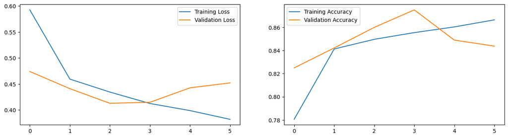

```python
plt.figure(figsize=(16, 4))
for i, metrics in enumerate(zip([losses, accs], [val_losses, val_accs], ['Loss', 'Accuracy'])):
    plt.subplot(1, 2, i + 1)
    plt.plot(range(epochs), metrics[0], label='Training {}'.format(metrics[2]))
    plt.plot(range(epochs), metrics[1], label='Validation {}'.format(metrics[2]))
    plt.legend()
plt.show()
```

#### Confusion Matrix

```python
preds2 = model2.predict(test_dataset)
```

```
119/119 ━━━━━━━━━━━━━━━━━━━━ 1s 10ms/step
```

```python
cm = sns.light_palette((260, 75, 60), input="husl", as_cmap=True)
```

```python
df = pd.DataFrame(preds2[0:15], columns = ['World','Sports','Business','Sci/Tech']).T
df.style.format("{:.2%}").background_gradient(cmap=cm)
```

|  | 0 | 1 | 2 | 3 | 4 | 5 | 6 | 7 | 8 | 9 | 10 | 11 | 12 | 13 | 14 |
| --- | --- | --- | --- | --- | --- | --- | --- | --- | --- | --- | --- | --- | --- | --- | --- |
| World | 0.03% | 99.96% | 0.17% | 1.27% | 99.99% | 3.60% | 0.27% | 10.58% | 98.85% | 0.17% | 99.95% | 0.02% | 0.06% | 98.14% | 99.96% |
| Sports | 99.97% | 0.00% | 0.00% | 98.67% | 0.00% | 0.36% | 99.71% | 87.96% | 0.39% | 0.01% | 0.01% | 0.01% | 0.00% | 0.81% | 0.00% |
| Business | 0.00% | 0.03% | 3.63% | 0.04% | 0.01% | 30.68% | 0.01% | 0.27% | 0.27% | 67.40% | 0.04% | 1.23% | 98.03% | 0.28% | 0.03% |
| Sci/Tech | 0.00% | 0.00% | 96.20% | 0.01% | 0.00% | 65.37% | 0.01% | 1.19% | 0.48% | 32.43% | 0.01% | 98.74% | 1.91% | 0.77% | 0.01% |

### Multi-Layer Unidirectional RNN

```python
model2 = tf.keras.Sequential([
                              encoder
                              ,tf.keras.layers.Embedding(len(encoder.get_vocabulary()), 64, mask_zero=True)
                              ,tf.keras.layers.SimpleRNN(64, return_sequences=True)
                              ,tf.keras.layers.SimpleRNN(32)
                              ,tf.keras.layers.Dense(64, activation='relu')
                              ,tf.keras.layers.Dropout(0.5)
                              ,tf.keras.layers.Dense(num_classes,activation='softmax')
])
results["Experiments B: RNN 4"] = {}
results["Experiments B: RNN 4"]["Architecture"] = "Multi-Layer Unidirectional RNN"
```

#### Compile Model

```python
model2.compile(optimizer='adam'
              ,loss=tf.keras.losses.SparseCategoricalCrossentropy()
              ,metrics=['accuracy'])
```

#### Train Model

```python
# Start time
start_time = time.time()

history2 = model2.fit(train_dataset
                    ,epochs=200
                    ,validation_data=validation_dataset
                    ,validation_steps=30
                    ,callbacks=[tf.keras.callbacks.EarlyStopping(monitor='val_accuracy', patience=2)]
                    )

# End time
end_time = time.time()

# Calculate and print the time taken
elapsed_time = end_time - start_time
print(f"Time taken to train Model: {elapsed_time:.2f} seconds")
results["Experiments B: RNN 4"]["Train Time"] = str(round(elapsed_time, 2)) + ' seconds'
```

```
1782/1782 ━━━━━━━━━━━━━━━━━━━━ 34s 18ms/step - accuracy: 0.6084 - loss: 0.8937 - val_accuracy: 0.7896 - val_loss: 0.6622
1782/1782 ━━━━━━━━━━━━━━━━━━━━ 32s 18ms/step - accuracy: 0.8203 - loss: 0.5266 - val_accuracy: 0.8438 - val_loss: 0.4569
1782/1782 ━━━━━━━━━━━━━━━━━━━━ 32s 18ms/step - accuracy: 0.8248 - loss: 0.5102 - val_accuracy: 0.8422 - val_loss: 0.4615
1782/1782 ━━━━━━━━━━━━━━━━━━━━ 31s 18ms/step - accuracy: 0.8309 - loss: 0.4926 - val_accuracy: 0.8542 - val_loss: 0.4290
1782/1782 ━━━━━━━━━━━━━━━━━━━━ 31s 18ms/step - accuracy: 0.8369 - loss: 0.4752 - val_accuracy: 0.8422 - val_loss: 0.4673
1782/1782 ━━━━━━━━━━━━━━━━━━━━ 31s 17ms/step - accuracy: 0.8433 - loss: 0.4576 - val_accuracy: 0.8177 - val_loss: 0.5004
Time taken to train Model: 191.07 seconds
```

```python
train_loss = history2.history['loss'][-1]  # Training loss from the last epoch
train_accuracy = history2.history['accuracy'][-1]  # Training accuracy from the last epoch
val_loss = history2.history['val_loss'][-1]  # Validation loss from the last epoch
val_accuracy = history2.history['val_accuracy'][-1]  # Validation accuracy from the last epoch

test_loss, test_acc = model2.evaluate(test_dataset)

print(f"Test Loss: {test_loss:.3f}, Test Accuracy: {test_acc:.3f}")
print(f"Training Loss: {train_loss:.3f}, Training Accuracy: {train_accuracy:.3f}")
print(f"Validation Loss: {val_loss:.3f}, Validation Accuracy: {val_accuracy:.3f}")

results["Experiments B: RNN 4"]["Test Accuracy"] = round(test_acc,3)
results["Experiments B: RNN 4"]["Test Loss"] = round(test_loss,3)
results["Experiments B: RNN 4"]["Train Accuracy"] = round(train_accuracy,3)
results["Experiments B: RNN 4"]["Train Loss"] = round(train_loss,3)
results["Experiments B: RNN 4"]["Validation Accuracy"] = round(val_accuracy,3)
results["Experiments B: RNN 4"]["Validation Loss"] = round(val_loss,3)
```

```
119/119 ━━━━━━━━━━━━━━━━━━━━ 1s 5ms/step - accuracy: 0.8313 - loss: 0.4860
Test Loss: 0.488, Test Accuracy: 0.830
Training Loss: 0.456, Training Accuracy: 0.844
Validation Loss: 0.500, Validation Accuracy: 0.818
```

#### Performance Metrics

```python
history_dict2 = history2.history
history_dict2.keys()
```

```
dict_keys(['accuracy', 'loss', 'val_accuracy', 'val_loss'])
```

```python
history2_df=pd.DataFrame(history_dict2)
history2_df.tail().round(3)
```

|  | accuracy | loss | val_accuracy | val_loss |
| --- | --- | --- | --- | --- |
| 1 | 0.822 | 0.519 | 0.844 | 0.457 |
| 2 | 0.826 | 0.509 | 0.842 | 0.461 |
| 3 | 0.832 | 0.490 | 0.854 | 0.429 |
| 4 | 0.838 | 0.476 | 0.842 | 0.467 |
| 5 | 0.844 | 0.456 | 0.818 | 0.500 |

```python
losses = history2.history['loss']
accs = history2.history['accuracy']
val_losses = history2.history['val_loss']
val_accs = history2.history['val_accuracy']
epochs = len(losses)
```

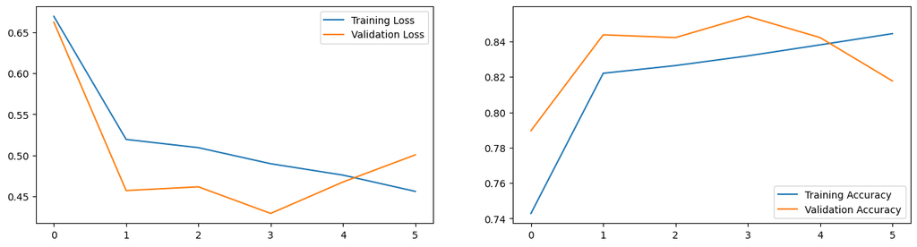

```python
plt.figure(figsize=(16, 4))
for i, metrics in enumerate(zip([losses, accs], [val_losses, val_accs], ['Loss', 'Accuracy'])):
    plt.subplot(1, 2, i + 1)
    plt.plot(range(epochs), metrics[0], label='Training {}'.format(metrics[2]))
    plt.plot(range(epochs), metrics[1], label='Validation {}'.format(metrics[2]))
    plt.legend()
plt.show()
```

#### Confusion Matrix

```python
preds2 = model2.predict(test_dataset)
```

```
119/119 ━━━━━━━━━━━━━━━━━━━━ 1s 6ms/step
```

```python
cm = sns.light_palette((260, 75, 60), input="husl", as_cmap=True)
```

```python
df = pd.DataFrame(preds2[0:15], columns = ['World','Sports','Business','Sci/Tech']).T
df.style.format("{:.2%}").background_gradient(cmap=cm)
```

|  | 0 | 1 | 2 | 3 | 4 | 5 | 6 | 7 | 8 | 9 | 10 | 11 | 12 | 13 | 14 |
| --- | --- | --- | --- | --- | --- | --- | --- | --- | --- | --- | --- | --- | --- | --- | --- |
| World | 1.93% | 99.58% | 0.47% | 1.62% | 98.88% | 3.36% | 0.94% | 7.53% | 78.01% | 1.88% | 98.99% | 0.77% | 1.99% | 94.01% | 98.71% |
| Sports | 98.02% | 0.01% | 0.02% | 98.30% | 0.02% | 0.55% | 99.00% | 88.79% | 1.09% | 0.03% | 0.02% | 0.19% | 0.00% | 0.68% | 0.02% |
| Business | 0.01% | 0.33% | 6.80% | 0.02% | 0.87% | 18.33% | 0.01% | 1.00% | 5.26% | 71.23% | 0.84% | 5.47% | 97.40% | 2.41% | 0.96% |
| Sci/Tech | 0.03% | 0.07% | 92.71% | 0.06% | 0.23% | 77.76% | 0.05% | 2.68% | 15.64% | 26.86% | 0.15% | 93.57% | 0.61% | 2.89% | 0.31% |

# Experiments C: LSTM

Try several experiments by tweaking (i) architecture (ii) Bidirectional/unidirectional & other hyper parameters, including regularization.

### Single Layer Bidirectional LSTM

```python
num_classes = 4
model = tf.keras.Sequential([
                              encoder
                              ,tf.keras.layers.Embedding(input_dim=len(encoder.get_vocabulary())
                              ,output_dim=64
                              ,mask_zero=True)
                              ,tf.keras.layers.Bidirectional(tf.keras.layers.LSTM(64))
                              ,tf.keras.layers.Dense(64, activation='relu')
                              ,tf.keras.layers.Dense(num_classes,activation='softmax')   # num_classes = 4
])
results["Experiments C: LSTM 1"] = {}
results["Experiments C: LSTM 1"]["Architecture"] = "Single Layer Bidirectional LSTM"
```

#### Compile Model

```python
model.compile(optimizer=tf.keras.optimizers.Adam(1e-4)
              ,loss=tf.keras.losses.SparseCategoricalCrossentropy()
              ,metrics=['accuracy'])
```

```python
print([layer.supports_masking for layer in model.layers])
```

```
[False, True, True, True, True]
```

#### Train the model

```python
# Start time
start_time = time.time()

history = model.fit(train_dataset
                    ,epochs = 200
                    ,validation_data=validation_dataset
                    ,callbacks=[tf.keras.callbacks.EarlyStopping(monitor='val_accuracy', patience=2)]
                    )

# End time
end_time = time.time()

# Calculate and print the time taken
elapsed_time = end_time - start_time
print(f"Time taken to train Model: {elapsed_time:.2f} seconds")
results["Experiments C: LSTM 1"]["Train Time"] = str(round(elapsed_time, 2)) + ' seconds'
```

```
1782/1782 ━━━━━━━━━━━━━━━━━━━━ 88s 49ms/step - accuracy: 0.5791 - loss: 1.0026 - val_accuracy: 0.8267 - val_loss: 0.5021
1782/1782 ━━━━━━━━━━━━━━━━━━━━ 197s 111ms/step - accuracy: 0.8287 - loss: 0.4814 - val_accuracy: 0.8500 - val_loss: 0.4315
1782/1782 ━━━━━━━━━━━━━━━━━━━━ 305s 171ms/step - accuracy: 0.8472 - loss: 0.4257 - val_accuracy: 0.8532 - val_loss: 0.4176
1782/1782 ━━━━━━━━━━━━━━━━━━━━ 84s 47ms/step - accuracy: 0.8542 - loss: 0.4018 - val_accuracy: 0.8615 - val_loss: 0.3931
1782/1782 ━━━━━━━━━━━━━━━━━━━━ 85s 48ms/step - accuracy: 0.8598 - loss: 0.3896 - val_accuracy: 0.8632 - val_loss: 0.3910
1782/1782 ━━━━━━━━━━━━━━━━━━━━ 85s 47ms/step - accuracy: 0.8605 - loss: 0.3816 - val_accuracy: 0.8605 - val_loss: 0.3866
1782/1782 ━━━━━━━━━━━━━━━━━━━━ 85s 48ms/step - accuracy: 0.8625 - loss: 0.3771 - val_accuracy: 0.8590 - val_loss: 0.3910
Time taken to train Model: 929.81 seconds
```

```python
train_loss = history.history['loss'][-1]  # Training loss from the last epoch
train_accuracy = history.history['accuracy'][-1]  # Training accuracy from the last epoch
val_loss = history.history['val_loss'][-1]  # Validation loss from the last epoch
val_accuracy = history.history['val_accuracy'][-1]  # Validation accuracy from the last epoch

test_loss, test_acc = model.evaluate(test_dataset)

print(f"Test Loss: {test_loss:.3f}, Test Accuracy: {test_acc:.3f}")
print(f"Training Loss: {train_loss:.3f}, Training Accuracy: {train_accuracy:.3f}")
print(f"Validation Loss: {val_loss:.3f}, Validation Accuracy: {val_accuracy:.3f}")

results["Experiments C: LSTM 1"]["Test Accuracy"] = round(test_acc,3)
results["Experiments C: LSTM 1"]["Test Loss"] = round(test_loss,3)
results["Experiments C: LSTM 1"]["Train Accuracy"] = round(train_accuracy,3)
results["Experiments C: LSTM 1"]["Train Loss"] = round(train_loss,3)
results["Experiments C: LSTM 1"]["Validation Accuracy"] = round(val_accuracy,3)
results["Experiments C: LSTM 1"]["Validation Loss"] = round(val_loss,3)
```

```
119/119 ━━━━━━━━━━━━━━━━━━━━ 2s 14ms/step - accuracy: 0.8472 - loss: 0.4131
Test Loss: 0.412, Test Accuracy: 0.846
Training Loss: 0.379, Training Accuracy: 0.861
Validation Loss: 0.391, Validation Accuracy: 0.859
```

#### Performance Metrics

```python
history_dict = history.history
history_dict.keys()
```

```
dict_keys(['accuracy', 'loss', 'val_accuracy', 'val_loss'])
```

```python
history_df=pd.DataFrame(history_dict)
history_df.tail(10).round(3)
```

|  | accuracy | loss | val_accuracy | val_loss |
| --- | --- | --- | --- | --- |
| 0 | 0.709 | 0.747 | 0.827 | 0.502 |
| 1 | 0.835 | 0.465 | 0.850 | 0.431 |
| 2 | 0.849 | 0.422 | 0.853 | 0.418 |
| 3 | 0.855 | 0.401 | 0.862 | 0.393 |
| 4 | 0.859 | 0.391 | 0.863 | 0.391 |
| 5 | 0.860 | 0.383 | 0.860 | 0.387 |
| 6 | 0.861 | 0.379 | 0.859 | 0.391 |

```python
losses = history.history['loss']
accs = history.history['accuracy']
val_losses = history.history['val_loss']
val_accs = history.history['val_accuracy']
epochs = len(losses)
```

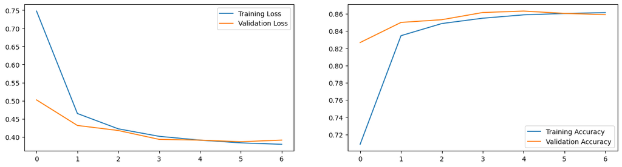

```python
plt.figure(figsize=(16, 4))
for i, metrics in enumerate(zip([losses, accs], [val_losses, val_accs], ['Loss', 'Accuracy'])):
    plt.subplot(1, 2, i + 1)
    plt.plot(range(epochs), metrics[0], label='Training {}'.format(metrics[2]))
    plt.plot(range(epochs), metrics[1], label='Validation {}'.format(metrics[2]))
    plt.legend()
plt.show()
```

#### Confusion Matrix

```python
preds = model.predict(test_dataset)
```

```
119/119 ━━━━━━━━━━━━━━━━━━━━ 1s 11ms/step
```

```python
cm = sns.light_palette((260, 75, 60), input="husl", as_cmap=True)
```

```python
df = pd.DataFrame(preds[0:15], columns = ['World','Sports','Business','Sci/Tech']).T
df.style.format("{:.2%}").background_gradient(cmap=cm)
```

|  | 0 | 1 | 2 | 3 | 4 | 5 | 6 | 7 | 8 | 9 | 10 | 11 | 12 | 13 | 14 |
| --- | --- | --- | --- | --- | --- | --- | --- | --- | --- | --- | --- | --- | --- | --- | --- |
| World | 0.18% | 99.94% | 0.15% | 1.74% | 99.84% | 0.85% | 1.24% | 50.89% | 95.23% | 3.84% | 99.97% | 0.37% | 1.07% | 96.04% | 99.86% |
| Sports | 99.70% | 0.00% | 0.00% | 98.06% | 0.00% | 0.08% | 98.39% | 44.26% | 0.15% | 0.04% | 0.00% | 0.16% | 0.03% | 0.26% | 0.00% |
| Business | 0.06% | 0.02% | 4.59% | 0.11% | 0.09% | 15.50% | 0.10% | 0.50% | 1.62% | 83.89% | 0.01% | 1.14% | 98.29% | 1.17% | 0.10% |
| Sci/Tech | 0.05% | 0.04% | 95.26% | 0.09% | 0.07% | 83.57% | 0.27% | 4.36% | 3.00% | 12.22% | 0.02% | 98.34% | 0.61% | 2.54% | 0.05% |

### Single Layer Unidirectional LSTM

```python
num_classes = 4
model = tf.keras.Sequential([
                              encoder
                              ,tf.keras.layers.Embedding(input_dim=len(encoder.get_vocabulary())
                              ,output_dim=64
                              ,mask_zero=True)
                              ,tf.keras.layers.LSTM(64)
                              ,tf.keras.layers.Dense(64, activation='relu')
                              ,tf.keras.layers.Dense(num_classes,activation='softmax')
])
results["Experiments C: LSTM 2"] = {}
results["Experiments C: LSTM 2"]["Architecture"] = "Single Layer Unidirectional LSTM"
```

#### Compile Model

```python
model.compile(optimizer=tf.keras.optimizers.Adam(1e-4)
              ,loss=tf.keras.losses.SparseCategoricalCrossentropy()
              ,metrics=['accuracy'])
```

#### Train Model

```python
# Start time
start_time = time.time()

history = model.fit(train_dataset
                    ,epochs = 200
                    ,validation_data=validation_dataset
                    ,callbacks=[tf.keras.callbacks.EarlyStopping(monitor='val_accuracy', patience=2)])


# End time
end_time = time.time()

# Calculate and print the time taken
elapsed_time = end_time - start_time
print(f"Time taken to train Model: {elapsed_time:.2f} seconds")
results["Experiments C: LSTM 2"]["Train Time"] = str(round(elapsed_time, 2)) + ' seconds'
```

```
1782/1782 ━━━━━━━━━━━━━━━━━━━━ 43s 24ms/step - accuracy: 0.5245 - loss: 1.0763 - val_accuracy: 0.8090 - val_loss: 0.5578
1782/1782 ━━━━━━━━━━━━━━━━━━━━ 42s 24ms/step - accuracy: 0.8168 - loss: 0.5191 - val_accuracy: 0.8360 - val_loss: 0.4731
1782/1782 ━━━━━━━━━━━━━━━━━━━━ 42s 23ms/step - accuracy: 0.8328 - loss: 0.4606 - val_accuracy: 0.8392 - val_loss: 0.4637
1782/1782 ━━━━━━━━━━━━━━━━━━━━ 42s 24ms/step - accuracy: 0.8375 - loss: 0.4454 - val_accuracy: 0.8407 - val_loss: 0.4504
1782/1782 ━━━━━━━━━━━━━━━━━━━━ 43s 24ms/step - accuracy: 0.8417 - loss: 0.4333 - val_accuracy: 0.8462 - val_loss: 0.4374
1782/1782 ━━━━━━━━━━━━━━━━━━━━ 43s 24ms/step - accuracy: 0.8434 - loss: 0.4274 - val_accuracy: 0.8460 - val_loss: 0.4309
1782/1782 ━━━━━━━━━━━━━━━━━━━━ 42s 24ms/step - accuracy: 0.8509 - loss: 0.4124 - val_accuracy: 0.8572 - val_loss: 0.4108
1782/1782 ━━━━━━━━━━━━━━━━━━━━ 43s 24ms/step - accuracy: 0.8561 - loss: 0.4004 - val_accuracy: 0.8572 - val_loss: 0.4050
1782/1782 ━━━━━━━━━━━━━━━━━━━━ 43s 24ms/step - accuracy: 0.8592 - loss: 0.3904 - val_accuracy: 0.8570 - val_loss: 0.3977
Time taken to train Model: 384.19 seconds
```

```python
train_loss = history.history['loss'][-1]  # Training loss from the last epoch
train_accuracy = history.history['accuracy'][-1]  # Training accuracy from the last epoch
val_loss = history.history['val_loss'][-1]  # Validation loss from the last epoch
val_accuracy = history.history['val_accuracy'][-1]  # Validation accuracy from the last epoch

test_loss, test_acc = model.evaluate(test_dataset)

print(f"Test Loss: {test_loss:.3f}, Test Accuracy: {test_acc:.3f}")
print(f"Training Loss: {train_loss:.3f}, Training Accuracy: {train_accuracy:.3f}")
print(f"Validation Loss: {val_loss:.3f}, Validation Accuracy: {val_accuracy:.3f}")

results["Experiments C: LSTM 2"]["Test Accuracy"] = round(test_acc,3)
results["Experiments C: LSTM 2"]["Test Loss"] = round(test_loss,3)
results["Experiments C: LSTM 2"]["Train Accuracy"] = round(train_accuracy,3)
results["Experiments C: LSTM 2"]["Train Loss"] = round(train_loss,3)
results["Experiments C: LSTM 2"]["Validation Accuracy"] = round(val_accuracy,3)
results["Experiments C: LSTM 2"]["Validation Loss"] = round(val_loss,3)
```

```
119/119 ━━━━━━━━━━━━━━━━━━━━ 1s 7ms/step - accuracy: 0.8542 - loss: 0.4097
Test Loss: 0.413, Test Accuracy: 0.852
Training Loss: 0.392, Training Accuracy: 0.860
Validation Loss: 0.398, Validation Accuracy: 0.857
```

#### Performance Metrics

```python
history_dict = history.history
history_dict.keys()
```

```
dict_keys(['accuracy', 'loss', 'val_accuracy', 'val_loss'])
```

```python
history_df=pd.DataFrame(history_dict)
history_df.tail(10).round(3)
```

|  | accuracy | loss | val_accuracy | val_loss |
| --- | --- | --- | --- | --- |
| 0 | 0.674 | 0.825 | 0.809 | 0.558 |
| 1 | 0.822 | 0.501 | 0.836 | 0.473 |
| 2 | 0.834 | 0.459 | 0.839 | 0.464 |
| 3 | 0.838 | 0.447 | 0.841 | 0.450 |
| 4 | 0.842 | 0.437 | 0.846 | 0.437 |
| 5 | 0.845 | 0.429 | 0.846 | 0.431 |
| 6 | 0.851 | 0.414 | 0.857 | 0.411 |
| 7 | 0.856 | 0.401 | 0.857 | 0.405 |
| 8 | 0.860 | 0.392 | 0.857 | 0.398 |

```python
losses = history.history['loss']
accs = history.history['accuracy']
val_losses = history.history['val_loss']
val_accs = history.history['val_accuracy']
epochs = len(losses)
```

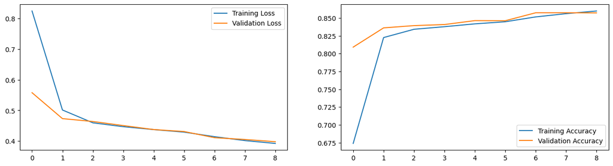

```python
plt.figure(figsize=(16, 4))
for i, metrics in enumerate(zip([losses, accs], [val_losses, val_accs], ['Loss', 'Accuracy'])):
    plt.subplot(1, 2, i + 1)
    plt.plot(range(epochs), metrics[0], label='Training {}'.format(metrics[2]))
    plt.plot(range(epochs), metrics[1], label='Validation {}'.format(metrics[2]))
    plt.legend()
plt.show()
```

#### Confusion Matrix

```python
preds = model.predict(test_dataset)
```

```
119/119 ━━━━━━━━━━━━━━━━━━━━ 1s 8ms/step
```

```python
cm = sns.light_palette((260, 75, 60), input="husl", as_cmap=True)
```

```python
df = pd.DataFrame(preds[0:15], columns = ['World','Sports','Business','Sci/Tech']).T
df.style.format("{:.2%}").background_gradient(cmap=cm)
```

|  | 0 | 1 | 2 | 3 | 4 | 5 | 6 | 7 | 8 | 9 | 10 | 11 | 12 | 13 | 14 |
| --- | --- | --- | --- | --- | --- | --- | --- | --- | --- | --- | --- | --- | --- | --- | --- |
| World | 1.36% | 99.95% | 0.13% | 1.32% | 99.77% | 0.76% | 1.06% | 17.18% | 92.66% | 1.72% | 99.96% | 0.49% | 0.63% | 94.16% | 99.81% |
| Sports | 98.43% | 0.00% | 0.00% | 98.48% | 0.01% | 0.08% | 98.69% | 80.66% | 1.48% | 0.04% | 0.00% | 0.06% | 0.01% | 1.42% | 0.00% |
| Business | 0.13% | 0.02% | 3.67% | 0.11% | 0.05% | 14.97% | 0.11% | 0.36% | 1.38% | 87.02% | 0.02% | 0.38% | 98.58% | 1.71% | 0.07% |
| Sci/Tech | 0.08% | 0.03% | 96.19% | 0.09% | 0.17% | 84.19% | 0.14% | 1.80% | 4.49% | 11.22% | 0.02% | 99.08% | 0.79% | 2.71% | 0.12% |

### Multi-Layer Bidirectional LSTM

```python
model2 = tf.keras.Sequential([
                              encoder
                              ,tf.keras.layers.Embedding(len(encoder.get_vocabulary()), 64, mask_zero=True)
                              ,tf.keras.layers.Bidirectional(tf.keras.layers.LSTM(64,  return_sequences=True))
                              ,tf.keras.layers.Bidirectional(tf.keras.layers.LSTM(32))
                              ,tf.keras.layers.Dense(64, activation='relu')
                              ,tf.keras.layers.Dropout(0.5)
                              ,tf.keras.layers.Dense(num_classes,activation='softmax')   # not binary since there are num_classes categories
])

results["Experiments C: LSTM 3"] = {}
results["Experiments C: LSTM 3"]["Architecture"] = "Multi-Layer Bidirectional LSTM"
```

#### Compile Model

```python
model2.compile(optimizer='adam'
              ,loss=tf.keras.losses.SparseCategoricalCrossentropy()
              ,metrics=['accuracy'])
```

#### Train Model

```python
# Start time
start_time = time.time()

history2 = model2.fit(train_dataset
                    ,epochs=200
                    ,validation_data=validation_dataset
                    ,validation_steps=30
                    ,callbacks=[tf.keras.callbacks.EarlyStopping(monitor='val_accuracy', patience=2)]
                    )

# End time
end_time = time.time()

# Calculate and print the time taken
elapsed_time = end_time - start_time
print(f"Time taken to train Model: {elapsed_time:.2f} seconds")
results["Experiments C: LSTM 3"]["Train Time"] = str(round(elapsed_time, 2)) + ' seconds'
```

```
1782/1782 ━━━━━━━━━━━━━━━━━━━━ 148s 81ms/step - accuracy: 0.7327 - loss: 0.6766 - val_accuracy: 0.8609 - val_loss: 0.3944
1782/1782 ━━━━━━━━━━━━━━━━━━━━ 150s 84ms/step - accuracy: 0.8484 - loss: 0.4350 - val_accuracy: 0.8604 - val_loss: 0.3927
1782/1782 ━━━━━━━━━━━━━━━━━━━━ 150s 84ms/step - accuracy: 0.8571 - loss: 0.4099 - val_accuracy: 0.8589 - val_loss: 0.4030
Time taken to train Model: 448.21 seconds
```

```python
train_loss = history2.history['loss'][-1]  # Training loss from the last epoch
train_accuracy = history2.history['accuracy'][-1]  # Training accuracy from the last epoch
val_loss = history2.history['val_loss'][-1]  # Validation loss from the last epoch
val_accuracy = history2.history['val_accuracy'][-1]  # Validation accuracy from the last epoch

test_loss, test_acc = model2.evaluate(test_dataset)

print(f"Test Loss: {test_loss:.3f}, Test Accuracy: {test_acc:.3f}")
print(f"Training Loss: {train_loss:.3f}, Training Accuracy: {train_accuracy:.3f}")
print(f"Validation Loss: {val_loss:.3f}, Validation Accuracy: {val_accuracy:.3f}")

results["Experiments C: LSTM 3"]["Test Accuracy"] = round(test_acc,3)
results["Experiments C: LSTM 3"]["Test Loss"] = round(test_loss,3)
results["Experiments C: LSTM 3"]["Train Accuracy"] = round(train_accuracy,3)
results["Experiments C: LSTM 3"]["Train Loss"] = round(train_loss,3)
results["Experiments C: LSTM 3"]["Validation Accuracy"] = round(val_accuracy,3)
results["Experiments C: LSTM 3"]["Validation Loss"] = round(val_loss,3)
```

```
119/119 ━━━━━━━━━━━━━━━━━━━━ 3s 24ms/step - accuracy: 0.8506 - loss: 0.4062
Test Loss: 0.416, Test Accuracy: 0.848
Training Loss: 0.409, Training Accuracy: 0.857
Validation Loss: 0.403, Validation Accuracy: 0.859
```

#### Performance Metrics

```python
history_dict2 = history2.history
history_dict2.keys()
```

```
dict_keys(['accuracy', 'loss', 'val_accuracy', 'val_loss'])
```

```python
history2_df=pd.DataFrame(history_dict2)
history2_df.tail().round(3)
```

|  | accuracy | loss | val_accuracy | val_loss |
| --- | --- | --- | --- | --- |
| 0 | 0.810 | 0.531 | 0.861 | 0.394 |
| 1 | 0.850 | 0.432 | 0.860 | 0.393 |
| 2 | 0.857 | 0.409 | 0.859 | 0.403 |

```python
losses = history2.history['loss']
accs = history2.history['accuracy']
val_losses = history2.history['val_loss']
val_accs = history2.history['val_accuracy']
epochs = len(losses)
```

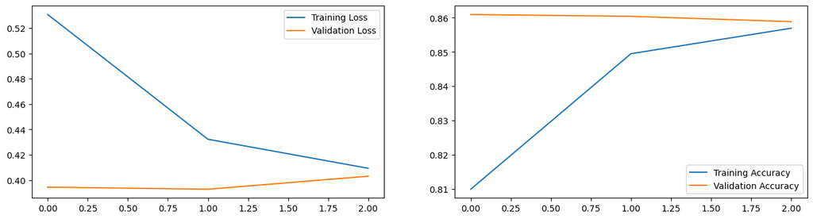

```python
plt.figure(figsize=(16, 4))
for i, metrics in enumerate(zip([losses, accs], [val_losses, val_accs], ['Loss', 'Accuracy'])):
    plt.subplot(1, 2, i + 1)
    plt.plot(range(epochs), metrics[0], label='Training {}'.format(metrics[2]))
    plt.plot(range(epochs), metrics[1], label='Validation {}'.format(metrics[2]))
    plt.legend()
plt.show()
```

#### Confusion Matrix

```python
preds = model.predict(test_dataset)
```

```
119/119 ━━━━━━━━━━━━━━━━━━━━ 1s 8ms/step
```

```python
preds.shape
```

```
(7600, 4)
```

```python
cm = sns.light_palette((260, 75, 60), input="husl", as_cmap=True)
```

```python
df = pd.DataFrame(preds[0:15], columns = ['World','Sports','Business','Sci/Tech']).T
df.style.format("{:.2%}").background_gradient(cmap=cm)
```

|  | 0 | 1 | 2 | 3 | 4 | 5 | 6 | 7 | 8 | 9 | 10 | 11 | 12 | 13 | 14 |
| --- | --- | --- | --- | --- | --- | --- | --- | --- | --- | --- | --- | --- | --- | --- | --- |
| World | 1.36% | 99.95% | 0.13% | 1.32% | 99.77% | 0.76% | 1.06% | 17.18% | 92.66% | 1.72% | 99.96% | 0.49% | 0.63% | 94.16% | 99.81% |
| Sports | 98.43% | 0.00% | 0.00% | 98.48% | 0.01% | 0.08% | 98.69% | 80.66% | 1.48% | 0.04% | 0.00% | 0.06% | 0.01% | 1.42% | 0.00% |
| Business | 0.13% | 0.02% | 3.67% | 0.11% | 0.05% | 14.97% | 0.11% | 0.36% | 1.38% | 87.02% | 0.02% | 0.38% | 98.58% | 1.71% | 0.07% |
| Sci/Tech | 0.08% | 0.03% | 96.19% | 0.09% | 0.17% | 84.19% | 0.14% | 1.80% | 4.49% | 11.22% | 0.02% | 99.08% | 0.79% | 2.71% | 0.12% |

### Multi-Layer Unidirectional LSTM

```python
model2 = tf.keras.Sequential([
                              encoder
                              ,tf.keras.layers.Embedding(len(encoder.get_vocabulary()), 64, mask_zero=True)
                              ,tf.keras.layers.LSTM(64, return_sequences=True)
                              ,tf.keras.layers.LSTM(32)
                              ,tf.keras.layers.Dense(64, activation='relu')
                              ,tf.keras.layers.Dropout(0.5)
                              ,tf.keras.layers.Dense(num_classes,activation='softmax')   # not binary since there are num_classes categories
])

results["Experiments C: LSTM 4"] = {}
results["Experiments C: LSTM 4"]["Architecture"] = "Multi-Layer Unidirectional LSTM"
```

#### Compile Model

```python
model2.compile(optimizer='adam'
              ,loss=tf.keras.losses.SparseCategoricalCrossentropy()
              ,metrics=['accuracy'])
```

#### Train Model

```python
# Start time
start_time = time.time()

history2 = model2.fit(train_dataset
                    ,epochs=200
                    ,validation_data=validation_dataset
                    ,validation_steps=30
                    ,callbacks=[tf.keras.callbacks.EarlyStopping(monitor='val_accuracy', patience=2)]
                    )

# End time
end_time = time.time()

# Calculate and print the time taken
elapsed_time = end_time - start_time
print(f"Time taken to train Model: {elapsed_time:.2f} seconds")
results["Experiments C: LSTM 4"]["Train Time"] = str(round(elapsed_time, 2)) + ' seconds'
```

```
1782/1782 ━━━━━━━━━━━━━━━━━━━━ 69s 38ms/step - accuracy: 0.7103 - loss: 0.7188 - val_accuracy: 0.8615 - val_loss: 0.4070
1782/1782 ━━━━━━━━━━━━━━━━━━━━ 69s 39ms/step - accuracy: 0.8469 - loss: 0.4431 - val_accuracy: 0.8536 - val_loss: 0.4172
1782/1782 ━━━━━━━━━━━━━━━━━━━━ 70s 39ms/step - accuracy: 0.8533 - loss: 0.4230 - val_accuracy: 0.8552 - val_loss: 0.4039
Time taken to train Model: 208.30 seconds
```

```python
train_loss = history2.history['loss'][-1]  # Training loss from the last epoch
train_accuracy = history2.history['accuracy'][-1]  # Training accuracy from the last epoch
val_loss = history2.history['val_loss'][-1]  # Validation loss from the last epoch
val_accuracy = history2.history['val_accuracy'][-1]  # Validation accuracy from the last epoch

test_loss, test_acc = model2.evaluate(test_dataset)

print(f"Test Loss: {test_loss:.3f}, Test Accuracy: {test_acc:.3f}")
print(f"Training Loss: {train_loss:.3f}, Training Accuracy: {train_accuracy:.3f}")
print(f"Validation Loss: {val_loss:.3f}, Validation Accuracy: {val_accuracy:.3f}")

results["Experiments C: LSTM 4"]["Test Accuracy"] = round(test_acc,3)
results["Experiments C: LSTM 4"]["Test Loss"] = round(test_loss,3)
results["Experiments C: LSTM 4"]["Train Accuracy"] = round(train_accuracy,3)
results["Experiments C: LSTM 4"]["Train Loss"] = round(train_loss,3)
results["Experiments C: LSTM 4"]["Validation Accuracy"] = round(val_accuracy,3)
results["Experiments C: LSTM 4"]["Validation Loss"] = round(val_loss,3)
```

```
119/119 ━━━━━━━━━━━━━━━━━━━━ 1s 12ms/step - accuracy: 0.8526 - loss: 0.4066
Test Loss: 0.411, Test Accuracy: 0.852
Training Loss: 0.422, Training Accuracy: 0.854
Validation Loss: 0.404, Validation Accuracy: 0.855
```

#### Performance Metrics

```python
history_dict2 = history2.history
history_dict2.keys()
```

```
dict_keys(['accuracy', 'loss', 'val_accuracy', 'val_loss'])
```

```python
history2_df=pd.DataFrame(history_dict2)
history2_df.tail().round(3)
```

|  | accuracy | loss | val_accuracy | val_loss |
| --- | --- | --- | --- | --- |
| 0 | 0.800 | 0.552 | 0.861 | 0.407 |
| 1 | 0.847 | 0.443 | 0.854 | 0.417 |
| 2 | 0.854 | 0.422 | 0.855 | 0.404 |

```python
losses = history2.history['loss']
accs = history2.history['accuracy']
val_losses = history2.history['val_loss']
val_accs = history2.history['val_accuracy']
epochs = len(losses)
```

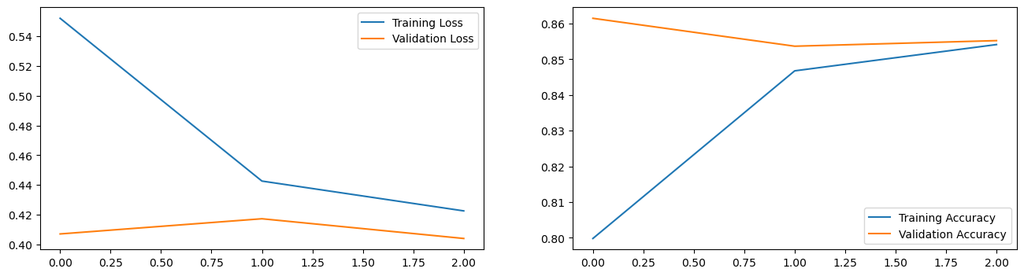

```python
plt.figure(figsize=(16, 4))
for i, metrics in enumerate(zip([losses, accs], [val_losses, val_accs], ['Loss', 'Accuracy'])):
    plt.subplot(1, 2, i + 1)
    plt.plot(range(epochs), metrics[0], label='Training {}'.format(metrics[2]))
    plt.plot(range(epochs), metrics[1], label='Validation {}'.format(metrics[2]))
    plt.legend()
plt.show()
```

#### Confusion Matrix

```python
preds = model.predict(test_dataset)
```

```
119/119 ━━━━━━━━━━━━━━━━━━━━ 1s 8ms/step
```

```python
cm = sns.light_palette((260, 75, 60), input="husl", as_cmap=True)
```

```python
df = pd.DataFrame(preds[0:15], columns = ['World','Sports','Business','Sci/Tech']).T
df.style.format("{:.2%}").background_gradient(cmap=cm)
```

|  | 0 | 1 | 2 | 3 | 4 | 5 | 6 | 7 | 8 | 9 | 10 | 11 | 12 | 13 | 14 |
| --- | --- | --- | --- | --- | --- | --- | --- | --- | --- | --- | --- | --- | --- | --- | --- |
| World | 1.36% | 99.95% | 0.13% | 1.32% | 99.77% | 0.76% | 1.06% | 17.18% | 92.66% | 1.72% | 99.96% | 0.49% | 0.63% | 94.16% | 99.81% |
| Sports | 98.43% | 0.00% | 0.00% | 98.48% | 0.01% | 0.08% | 98.69% | 80.66% | 1.48% | 0.04% | 0.00% | 0.06% | 0.01% | 1.42% | 0.00% |
| Business | 0.13% | 0.02% | 3.67% | 0.11% | 0.05% | 14.97% | 0.11% | 0.36% | 1.38% | 87.02% | 0.02% | 0.38% | 98.58% | 1.71% | 0.07% |
| Sci/Tech | 0.08% | 0.03% | 96.19% | 0.09% | 0.17% | 84.19% | 0.14% | 1.80% | 4.49% | 11.22% | 0.02% | 99.08% | 0.79% | 2.71% | 0.12% |

# Experiment D: 1D CNN

### Single Layer CNN

```python
model = tf.keras.models.Sequential([encoder, tf.keras.layers.Embedding(input_dim = len(encoder.get_vocabulary()),
                                                                       output_dim = 128, mask_zero = True),
                                    tf.keras.layers.Conv1D(filters = 128,
                                                           kernel_size = 7,
                                                           padding = 'valid',
                                                           activation = 'relu',
                                                           strides = 3),
                                    tf.keras.layers.GlobalMaxPooling1D(),
                                    tf.keras.layers.Dense(units = 128,
                                                          activation = 'relu'),
                                    tf.keras.layers.Dense(4, activation = tf.nn.softmax)
                                                          ])

results["Experiments D: 1D CNN 1"] = {}
results["Experiments D: 1D CNN 1"]["Architecture"] = "Single Layer CNN"
```

#### Compile Model

```python
model.compile(optimizer = tf.keras.optimizers.Adam(1e-4),
              loss=tf.keras.losses.SparseCategoricalCrossentropy(),
              metrics=['accuracy'])
```

```python
print([layer.supports_masking for layer in model.layers])
```

```
[False, True, False, False, True, True]
```

#### Train Model

```python
# Start time
start_time = time.time()

history = model.fit(train_dataset
                    ,epochs = 200
                    ,validation_data=validation_dataset
                    ,callbacks=[tf.keras.callbacks.EarlyStopping(monitor='val_accuracy', patience=2)]
                    )

# End time
end_time = time.time()

# Calculate and print the time taken
elapsed_time = end_time - start_time
print(f"Time taken to train Model: {elapsed_time:.2f} seconds")
results["Experiments D: 1D CNN 1"]["Train Time"] = str(round(elapsed_time, 2)) + ' seconds'
```

```
1782/1782 ━━━━━━━━━━━━━━━━━━━━ 13s 7ms/step - accuracy: 0.5526 - loss: 1.0615 - val_accuracy: 0.8505 - val_loss: 0.4415
1782/1782 ━━━━━━━━━━━━━━━━━━━━ 14s 8ms/step - accuracy: 0.8502 - loss: 0.4205 - val_accuracy: 0.8608 - val_loss: 0.4081
1782/1782 ━━━━━━━━━━━━━━━━━━━━ 15s 9ms/step - accuracy: 0.8587 - loss: 0.3883 - val_accuracy: 0.8592 - val_loss: 0.4008
1782/1782 ━━━━━━━━━━━━━━━━━━━━ 17s 9ms/step - accuracy: 0.8680 - loss: 0.3678 - val_accuracy: 0.8603 - val_loss: 0.3958
Time taken to train Model: 58.82 seconds
```

```python
train_loss = history.history['loss'][-1]  # Training loss from the last epoch
train_accuracy = history.history['accuracy'][-1]  # Training accuracy from the last epoch
val_loss = history.history['val_loss'][-1]  # Validation loss from the last epoch
val_accuracy = history.history['val_accuracy'][-1]  # Validation accuracy from the last epoch

test_loss, test_acc = model.evaluate(test_dataset)

print(f"Test Loss: {test_loss:.3f}, Test Accuracy: {test_acc:.3f}")
print(f"Training Loss: {train_loss:.3f}, Training Accuracy: {train_accuracy:.3f}")
print(f"Validation Loss: {val_loss:.3f}, Validation Accuracy: {val_accuracy:.3f}")

results["Experiments D: 1D CNN 1"]["Test Accuracy"] = round(test_acc,3)
results["Experiments D: 1D CNN 1"]["Test Loss"] = round(test_loss,3)
results["Experiments D: 1D CNN 1"]["Train Accuracy"] = round(train_accuracy,3)
results["Experiments D: 1D CNN 1"]["Train Loss"] = round(train_loss,3)
results["Experiments D: 1D CNN 1"]["Validation Accuracy"] = round(val_accuracy,3)
results["Experiments D: 1D CNN 1"]["Validation Loss"] = round(val_loss,3)
```

```
119/119 ━━━━━━━━━━━━━━━━━━━━ 0s 3ms/step - accuracy: 0.8552 - loss: 0.4113
Test Loss: 0.412, Test Accuracy: 0.854
Training Loss: 0.366, Training Accuracy: 0.869
Validation Loss: 0.396, Validation Accuracy: 0.860
```

#### Performance Metrics

```python
history_dict = history.history
history_dict.keys()
```

```
dict_keys(['accuracy', 'loss', 'val_accuracy', 'val_loss'])
```

```python
history_df=pd.DataFrame(history_dict)
history_df.tail(10).round(3)
```

|  | accuracy | loss | val_accuracy | val_loss |
| --- | --- | --- | --- | --- |
| 0 | 0.718 | 0.747 | 0.850 | 0.441 |
| 1 | 0.853 | 0.413 | 0.861 | 0.408 |
| 2 | 0.862 | 0.385 | 0.859 | 0.401 |
| 3 | 0.869 | 0.366 | 0.860 | 0.396 |

```python
losses = history.history['loss']
accs = history.history['accuracy']
val_losses = history.history['val_loss']
val_accs = history.history['val_accuracy']
epochs = len(losses)
```

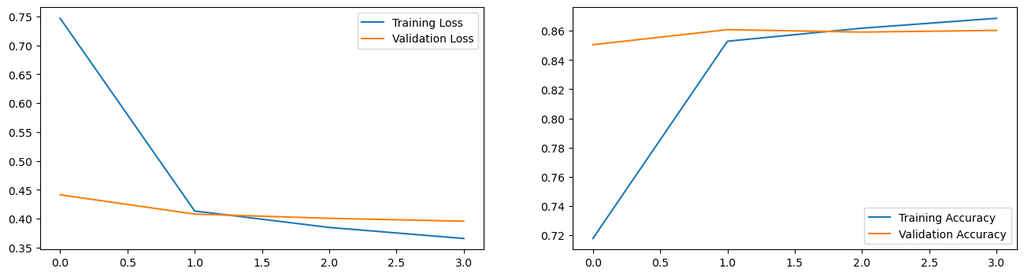

```python
plt.figure(figsize=(16, 4))
for i, metrics in enumerate(zip([losses, accs], [val_losses, val_accs], ['Loss', 'Accuracy'])):
    plt.subplot(1, 2, i + 1)
    plt.plot(range(epochs), metrics[0], label='Training {}'.format(metrics[2]))
    plt.plot(range(epochs), metrics[1], label='Validation {}'.format(metrics[2]))
    plt.legend()
plt.show()
```

#### Confusion Matrix

```python
preds = model.predict(test_dataset)
```

```
119/119 ━━━━━━━━━━━━━━━━━━━━ 0s 4ms/step
```

```python
cm = sns.light_palette((260, 75, 60), input="husl", as_cmap=True)
```

```python
df = pd.DataFrame(preds[0:15], columns = ['World','Sports','Business','Sci/Tech']).T
df.style.format("{:.2%}").background_gradient(cmap=cm)
```

|  | 0 | 1 | 2 | 3 | 4 | 5 | 6 | 7 | 8 | 9 | 10 | 11 | 12 | 13 | 14 |
| --- | --- | --- | --- | --- | --- | --- | --- | --- | --- | --- | --- | --- | --- | --- | --- |
| World | 0.28% | 99.90% | 0.15% | 1.32% | 99.82% | 0.78% | 0.82% | 17.38% | 94.87% | 1.87% | 99.99% | 0.40% | 1.50% | 96.84% | 99.71% |
| Sports | 99.65% | 0.02% | 0.02% | 98.54% | 0.02% | 0.07% | 99.08% | 81.50% | 0.25% | 0.09% | 0.00% | 3.03% | 0.11% | 0.97% | 0.01% |
| Business | 0.02% | 0.06% | 4.53% | 0.06% | 0.08% | 17.57% | 0.04% | 0.02% | 1.40% | 74.30% | 0.00% | 0.55% | 95.70% | 1.12% | 0.13% |
| Sci/Tech | 0.05% | 0.01% | 95.30% | 0.09% | 0.09% | 81.58% | 0.06% | 1.10% | 3.48% | 23.75% | 0.00% | 96.02% | 2.70% | 1.06% | 0.15% |

### Multi Layer CNN

```python
model = tf.keras.models.Sequential([encoder, tf.keras.layers.Embedding(input_dim = len(encoder.get_vocabulary()),
                                                                       output_dim = 128, mask_zero = True),
                                    tf.keras.layers.Conv1D(filters = 128,
                                                           kernel_size = 7,
                                                           padding = 'valid',
                                                           activation = 'relu',
                                                           strides = 3),
                                    tf.keras.layers.Conv1D(filters = 128,
                                                           kernel_size = 7,
                                                           padding = 'valid',
                                                           activation = 'relu',
                                                           strides = 3),
                                    tf.keras.layers.GlobalMaxPooling1D(),
                                    tf.keras.layers.Dense(units = 128,
                                                          activation = 'relu'),
                                    tf.keras.layers.Dense(4, activation = tf.nn.softmax)
                                                          ])

results["Experiments D: 1D CNN 2"] = {}
results["Experiments D: 1D CNN 2"]["Architecture"] = "Multi Layer CNN"
```

#### Compile Model

```python
model.compile(optimizer = tf.keras.optimizers.Adam(1e-4),
              loss=tf.keras.losses.SparseCategoricalCrossentropy(),
              metrics=['accuracy'])
```

```python
print([layer.supports_masking for layer in model.layers])
```

```
[False, True, False, False, False, True, True]
```

#### Model Train

```python
# Start time
start_time = time.time()

history = model.fit(train_dataset
                    ,epochs = 200
                    ,validation_data=validation_dataset
                    ,callbacks=[tf.keras.callbacks.EarlyStopping(monitor='val_accuracy', patience=2)]
                    )

# End time
end_time = time.time()

# Calculate and print the time taken
elapsed_time = end_time - start_time
print(f"Time taken to train Model: {elapsed_time:.2f} seconds")
results["Experiments D: 1D CNN 2"]["Train Time"] = str(round(elapsed_time, 2)) + ' seconds'
```

```
1782/1782 ━━━━━━━━━━━━━━━━━━━━ 24s 13ms/step - accuracy: 0.5509 - loss: 0.9825 - val_accuracy: 0.8452 - val_loss: 0.4404
1782/1782 ━━━━━━━━━━━━━━━━━━━━ 25s 14ms/step - accuracy: 0.8490 - loss: 0.4160 - val_accuracy: 0.8590 - val_loss: 0.3962
1782/1782 ━━━━━━━━━━━━━━━━━━━━ 24s 14ms/step - accuracy: 0.8599 - loss: 0.3866 - val_accuracy: 0.8630 - val_loss: 0.3898
1782/1782 ━━━━━━━━━━━━━━━━━━━━ 24s 14ms/step - accuracy: 0.8647 - loss: 0.3698 - val_accuracy: 0.8633 - val_loss: 0.3866
1782/1782 ━━━━━━━━━━━━━━━━━━━━ 24s 14ms/step - accuracy: 0.8692 - loss: 0.3560 - val_accuracy: 0.8650 - val_loss: 0.3811
1782/1782 ━━━━━━━━━━━━━━━━━━━━ 23s 13ms/step - accuracy: 0.8736 - loss: 0.3445 - val_accuracy: 0.8640 - val_loss: 0.3813
1782/1782 ━━━━━━━━━━━━━━━━━━━━ 23s 13ms/step - accuracy: 0.8799 - loss: 0.3289 - val_accuracy: 0.8630 - val_loss: 0.3848
Time taken to train Model: 169.10 seconds
```

```python
train_loss = history.history['loss'][-1]  # Training loss from the last epoch
train_accuracy = history.history['accuracy'][-1]  # Training accuracy from the last epoch
val_loss = history.history['val_loss'][-1]  # Validation loss from the last epoch
val_accuracy = history.history['val_accuracy'][-1]  # Validation accuracy from the last epoch

test_loss, test_acc = model.evaluate(test_dataset)

print(f"Test Loss: {test_loss:.3f}, Test Accuracy: {test_acc:.3f}")
print(f"Training Loss: {train_loss:.3f}, Training Accuracy: {train_accuracy:.3f}")
print(f"Validation Loss: {val_loss:.3f}, Validation Accuracy: {val_accuracy:.3f}")

results["Experiments D: 1D CNN 2"]["Test Accuracy"] = round(test_acc,3)
results["Experiments D: 1D CNN 2"]["Test Loss"] = round(test_loss,3)
results["Experiments D: 1D CNN 2"]["Train Accuracy"] = round(train_accuracy,3)
results["Experiments D: 1D CNN 2"]["Train Loss"] = round(train_loss,3)
results["Experiments D: 1D CNN 2"]["Validation Accuracy"] = round(val_accuracy,3)
results["Experiments D: 1D CNN 2"]["Validation Loss"] = round(val_loss,3)
```

```
119/119 ━━━━━━━━━━━━━━━━━━━━ 0s 4ms/step - accuracy: 0.8516 - loss: 0.4060
Test Loss: 0.407, Test Accuracy: 0.852
Training Loss: 0.329, Training Accuracy: 0.880
Validation Loss: 0.385, Validation Accuracy: 0.863
```

#### Performance Metrics

```python
history_dict = history.history
history_dict.keys()
```

```
dict_keys(['accuracy', 'loss', 'val_accuracy', 'val_loss'])
```

```python
history_df=pd.DataFrame(history_dict)
history_df.tail(10).round(3)
```

|  | accuracy | loss | val_accuracy | val_loss |
| --- | --- | --- | --- | --- |
| 0 | 0.723 | 0.681 | 0.845 | 0.440 |
| 1 | 0.852 | 0.409 | 0.859 | 0.396 |
| 2 | 0.861 | 0.385 | 0.863 | 0.390 |
| 3 | 0.865 | 0.370 | 0.863 | 0.387 |
| 4 | 0.870 | 0.356 | 0.865 | 0.381 |
| 5 | 0.875 | 0.343 | 0.864 | 0.381 |
| 6 | 0.880 | 0.329 | 0.863 | 0.385 |

```python
losses = history.history['loss']
accs = history.history['accuracy']
val_losses = history.history['val_loss']
val_accs = history.history['val_accuracy']
epochs = len(losses)
```

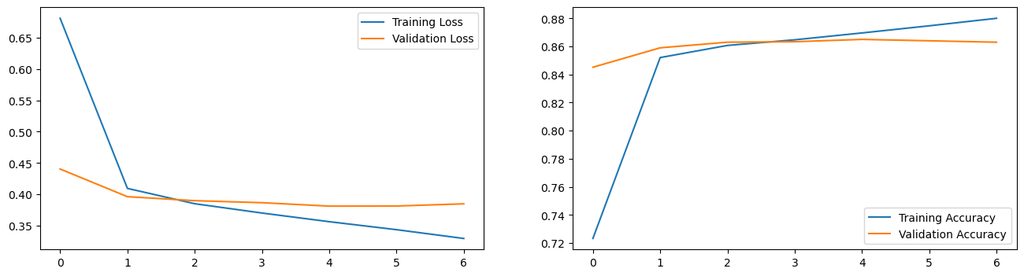

```python
plt.figure(figsize=(16, 4))
for i, metrics in enumerate(zip([losses, accs], [val_losses, val_accs], ['Loss', 'Accuracy'])):
    plt.subplot(1, 2, i + 1)
    plt.plot(range(epochs), metrics[0], label='Training {}'.format(metrics[2]))
    plt.plot(range(epochs), metrics[1], label='Validation {}'.format(metrics[2]))
    plt.legend()
plt.show()
```

#### Confusion Matrix

```python
preds = model.predict(test_dataset)
```

```
119/119 ━━━━━━━━━━━━━━━━━━━━ 1s 4ms/step
```

```python
preds.shape
```

```
(7600, 4)
```

```python
cm = sns.light_palette((260, 75, 60), input="husl", as_cmap=True)
```

```python
df = pd.DataFrame(preds[0:15], columns = ['World','Sports','Business','Sci/Tech']).T
df.style.format("{:.2%}").background_gradient(cmap=cm)
```

|  | 0 | 1 | 2 | 3 | 4 | 5 | 6 | 7 | 8 | 9 | 10 | 11 | 12 | 13 | 14 |
| --- | --- | --- | --- | --- | --- | --- | --- | --- | --- | --- | --- | --- | --- | --- | --- |
| World | 0.12% | 99.86% | 0.14% | 1.54% | 99.62% | 0.61% | 1.56% | 19.57% | 94.65% | 0.83% | 99.97% | 0.07% | 1.00% | 97.50% | 99.89% |
| Sports | 99.88% | 0.00% | 0.00% | 98.35% | 0.00% | 0.09% | 97.99% | 79.84% | 0.21% | 0.02% | 0.00% | 0.11% | 0.01% | 0.19% | 0.00% |
| Business | 0.00% | 0.13% | 3.95% | 0.07% | 0.09% | 24.22% | 0.14% | 0.03% | 1.97% | 66.52% | 0.03% | 0.25% | 97.96% | 1.23% | 0.09% |
| Sci/Tech | 0.00% | 0.01% | 95.91% | 0.04% | 0.28% | 75.07% | 0.30% | 0.57% | 3.17% | 32.63% | 0.00% | 99.57% | 1.04% | 1.08% | 0.02% |

# Result

**Result:** Create a table with the accuracy and loss for train/test/validation & process time for all the models

```python
from IPython.display import display, HTML
# Convert the dictionary to a DataFrame
resultDf = pd.DataFrame(results).T
```

```python
# Display the table with proper HTML rendering for line breaks
display(HTML(resultDf.to_html(escape=False)))
```

|  | Architecture | Train Time | Test Accuracy | Test Loss | Train Accuracy | Train Loss | Validation Accuracy | Validation Loss |
| --- | --- | --- | --- | --- | --- | --- | --- | --- |
| Experiments B: RNN 1 | Bidirectional Simple RNN | 367.28 seconds | 0.857 | 0.392 | 0.872 | 0.351 | 0.865 | 0.383 |
| Experiments B: RNN 2 | Unidirectional Single Layer Simple RNN | 266.3 seconds | 0.845 | 0.433 | 0.873 | 0.354 | 0.853 | 0.416 |
| Experiments B: RNN 3 | Multi-Layer Bidirectional RNN | 473.41 seconds | 0.847 | 0.453 | 0.866 | 0.382 | 0.844 | 0.452 |
| Experiments B: RNN 4 | Multi-Layer Unidirectional RNN | 191.07 seconds | 0.83 | 0.488 | 0.844 | 0.456 | 0.818 | 0.5 |
| Experiments C: LSTM 1 | Single Layer Bidirectional LSTM | 929.81 seconds | 0.846 | 0.412 | 0.861 | 0.379 | 0.859 | 0.391 |
| Experiments C: LSTM 2 | Single Layer Unidirectional LSTM | 384.19 seconds | 0.852 | 0.413 | 0.86 | 0.392 | 0.857 | 0.398 |
| Experiments C: LSTM 3 | Multi-Layer Bidirectional LSTM | 448.21 seconds | 0.848 | 0.416 | 0.857 | 0.409 | 0.859 | 0.403 |
| Experiments C: LSTM 4 | Multi-Layer Unidirectional LSTM | 208.3 seconds | 0.852 | 0.411 | 0.854 | 0.422 | 0.855 | 0.404 |
| Experiments D: 1D CNN 1 | Single Layer CNN | 58.82 seconds | 0.854 | 0.412 | 0.869 | 0.366 | 0.86 | 0.396 |
| Experiments D: 1D CNN 2 | Multi Layer CNN | 169.1 seconds | 0.852 | 0.407 | 0.88 | 0.329 | 0.863 | 0.385 |